# Name: Bosan Hsu

### Date: 8/15/2025 - 8/24/2025

# Introduction

The purpose of this project is to gauge your technical skills and problem solving ability by working through something similar to a real NBA data science project. You will work your way through this R Markdown document, answering questions as you go along. Please begin by adding your name to the "author" key in the YAML header. When you're finished with the document, come back and type your answers into the answer key at the top. Please leave all your work below and have your answers where indicated below as well. Please note that we will be reviewing your code so make it clear, concise, and **avoid long printouts.** Feel free to add in as many new code chunks as you'd like.

Remember that we will be grading the quality of your code and visuals alongside the correctness of your answers. Please try to use the tidyverse as much as possible (instead of base R and explicit loops). Please do not bring in any outside data, and use the provided data as truth (for example, some "home" games have been played at secondary locations, including TOR's entire 2020-21 season. These are not reflected in the data and you do not need to account for this.) Note that the OKC and DEN 2024-25 schedules in `schedule_24_partial.csv` intentionally include only 80 games, as the league holds 2 games out for each team in the middle of December due to unknown NBA Cup matchups. Do not assign specific games to fill those two slots.

**Note:**

**Throughout this document, any `season` column represents the year each season started. For example, the 2015-16 season will be in the dataset as 2015. We may refer to a season by just this number (e.g. 2015) instead of the full text (e.g. 2015-16).**

# Answers

## Part 1

**Question 1:** 26 4-in-6 stretches in OKC's draft schedule.

**Question 2:** 25.1 4-in-6 stretches on average.

**Question 3:**

- Most 4-in-6 stretches on average: CHA (28.1)
- Fewest 4-in-6 stretches on average: NYK (22.2)

**Question 4:** This is a written question. Please leave your response in the document under Question 4.

**Question 5:**

- BKN Defensive eFG%: 54.3%
- When opponent on a B2B: 53.5%

## Part 2

Please show your work in the document, you don't need anything here.

## Part 3

**Question 8:**

- Most Helped by Schedule: SAC (2.35 wins)
- Most Hurt by Schedule: NOP (-2.74 wins)

# Setup and Data

```python
import pandas as pd
# Note, you will likely have to change these paths. If your data is in the same folder as this project,
# the paths will likely be fixed for you by deleting ../../Data/schedule_project/ from each string.
schedule = pd.read_csv("schedule.csv")
draft_schedule = pd.read_csv("schedule_24_partial.csv")
locations = pd.read_csv("locations.csv")
game_data = pd.read_csv("team_game_data.csv")
```

```python
schedule.head(1)
```

|  | season | gamedate | team | opponent | home | win |
| --- | --- | --- | --- | --- | --- | --- |
| 0 | 2014 | 2015-04-15 | SAC | LAL | 0 | 1 |

```python
draft_schedule.head(1)
```

|  | season | gamedate | team | opponent | home | win |
| --- | --- | --- | --- | --- | --- | --- |
| 0 | 2024 | 2025-04-13 | DEN | HOU | 0 | 1 |

```python
locations.head(1)
```

|  | team | latitude | longitude | timezone |
| --- | --- | --- | --- | --- |
| 0 | ATL | 33.757233 | -84.39634 | Eastern |

```python
game_data.head(1)
```

|  | season | gametype | nbagameid | gamedate | offensivenbateamid | off_team_name | off_team | off_home | off_win | defensivenbateamid | ... | turnovers | blocksagainst | defensivefouls | offensivefouls | shootingfoulsdrawn | possessions | points | shotattempts | andones | shotattemptpoints |
| --- | --- | --- | --- | --- | --- | --- | --- | --- | --- | --- | --- | --- | --- | --- | --- | --- | --- | --- | --- | --- | --- |
| 0 | 2016 | 2 | 21600495 | 2016-12-30 | 1610612740 | New Orleans Pelicans | NOP | 1 | 1 | 1610612752 | ... | 13 | 6 | 17 | 1 | 9 | 101 | 104 | 91 | 3 | 102 |

1 rows × 41 columns

## Part 1 -- Schedule Analysis

In this section, you're going to work to answer questions using NBA scheduling data.

### Question 1

**QUESTION:** How many times are the Thunder scheduled to play 4 games in 6 nights in the provided 80-game draft of the 2024-25 season schedule? (Note: clarification, the stretches can overlap, the question is really “How many games are the 4th game played over the past 6 nights?”)

```python
draft_schedule.dtypes
```

|  | 0 |
| --- | --- |
| season | int64 |
| gamedate | object |
| team | object |
| opponent | object |
| home | int64 |
| win | int64 |

**dtype:** object

```python
draft_schedule["gamedate"] = pd.to_datetime(draft_schedule["gamedate"])
```

```python
def count_x_in_y(schedule: pd.DataFrame, team: str, x: int = 4, y: int = 6):

    team_schedule = schedule[schedule["team"] == team].copy()
    team_schedule = team_schedule.sort_values("gamedate").reset_index(drop=True)

    counts = []
    for end_date in team_schedule["gamedate"]:
        start_date = end_date - pd.Timedelta(days = y - 1)
        game_count = ((team_schedule["gamedate"] >= start_date) & (team_schedule["gamedate"] <= end_date)).sum()
        counts.append(game_count)

    team_schedule[f"games_in_last_{y}_nights"] = counts
    team_schedule[f"{x}_games_in_past_{y}_nights"] = (team_schedule[f"games_in_last_{y}_nights"] == x)

    total = int(team_schedule[f"{x}_games_in_past_{y}_nights"].sum())
    return team_schedule, total
```

```python
print(count_x_in_y(schedule = draft_schedule, team = "OKC", x = 4, y = 6))
```

```
(    season   gamedate team opponent  home  win  games_in_last_6_nights  \
0     2024 2024-10-24  OKC      DEN     0    1                       1
1     2024 2024-10-26  OKC      CHI     0    1                       2
2     2024 2024-10-27  OKC      ATL     1    1                       3
3     2024 2024-10-30  OKC      SAS     1    1                       3
4     2024 2024-11-01  OKC      POR     0    1                       3
..     ...        ...  ...      ...   ...  ...                     ...
75    2024 2025-04-06  OKC      LAL     1    0                       3
76    2024 2025-04-08  OKC      LAL     1    1                       3
77    2024 2025-04-09  OKC      PHX     0    1                       4
78    2024 2025-04-11  OKC      UTA     0    1                       4
79    2024 2025-04-13  OKC      NOP     0    1                       4

    4_games_in_past_6_nights
0                      False
1                      False
2                      False
3                      False
4                      False
..                       ...
75                     False
76                     False
77                      True
78                      True
79                      True

[80 rows x 8 columns], 26)
```

**ANSWER 1:**

26 4-in-6 stretches in OKC's draft schedule.

### Question 2

**QUESTION:** From 2014-15 to 2023-24, what is the average number of 4-in-6 stretches for a team in a season? Adjust each team/season to per-82 games before taking your final average.

```python
schedule.dtypes
```

|  | 0 |
| --- | --- |
| season | int64 |
| gamedate | object |
| team | object |
| opponent | object |
| home | int64 |
| win | int64 |

**dtype:** object

```python
schedule["gamedate"] = pd.to_datetime(schedule["gamedate"])
```

```python
def count_x_in_y_v2(schedule: pd.DataFrame, team: str, x: int = 4, y: int = 6):

    team_schedule = schedule[schedule["team"] == team].copy()
    team_schedule = team_schedule.sort_values("gamedate").reset_index(drop=True)

    counts = []
    for end_date in team_schedule["gamedate"]:
        start_date = end_date - pd.Timedelta(days = y - 1)
        game_count = ((team_schedule["gamedate"] >= start_date) & (team_schedule["gamedate"] <= end_date)).sum()
        counts.append(game_count)

    team_schedule[f"games_in_last_{y}_nights"] = counts
    team_schedule[f"{x}_games_in_past_{y}_nights"] = (team_schedule[f"games_in_last_{y}_nights"] == x)

    total = int(team_schedule[f"{x}_games_in_past_{y}_nights"].sum())
    return total # I removed season schedule output in Q2 to avoid unnecessary data storage.
```

```python
def team_games_by_season(schedule: pd.DataFrame):

    team_games_by_season = (schedule
                            .groupby(["season", "team"], as_index=False)["gamedate"].count()
                            .rename(columns={"gamedate": "games"})
                            .sort_values(["season", "team"])
                            .reset_index(drop=True)
                            )

    return team_games_by_season

team_x_season = team_games_by_season(schedule)
team_x_season.head(3)
```

|  | season | team | games |
| --- | --- | --- | --- |
| 0 | 2014 | ATL | 82 |
| 1 | 2014 | BKN | 82 |
| 2 | 2014 | BOS | 82 |

```python
# Check if every team had the same number of games in the same season
team_x_season.groupby(["season"], as_index=False)["games"].nunique()
```

|  | season | games |
| --- | --- | --- |
| 0 | 2014 | 1 |
| 1 | 2015 | 1 |
| 2 | 2016 | 1 |
| 3 | 2017 | 1 |
| 4 | 2018 | 1 |
| 5 | 2019 | 9 |
| 6 | 2020 | 1 |
| 7 | 2021 | 1 |
| 8 | 2022 | 1 |
| 9 | 2023 | 1 |

```python
# In the 2019–20 season, teams played different numbers of games because of COVID-19.
# My plan is to compute each team’s 4-in-6 count in a season, convert it to a per-82 rate,
# then average across the 30 teams.
# I’ll repeat this for each season, then take the average across seasons.

def each_season_avg_x_in_y(schedule: pd.DataFrame, team_x_season: pd.DataFrame, x: int = 4, y: int = 6)-> float:

    schedule = schedule.copy()

    all_seasons_league_4_in_6_total = 0
    number_of_seasons = team_x_season["season"].nunique()

    for season in sorted(team_x_season["season"].unique()):

        league_4_in_6_total = 0

        season_schedule = schedule[schedule["season"] == season].copy()
        season_schedule = season_schedule.sort_values("gamedate").reset_index(drop=True)

        for team in team_x_season[team_x_season["season"] == season]["team"]:

            team_games_in_season = team_x_season[(team_x_season["season"] == season)
                                                & (team_x_season["team"] == team)]["games"].iloc[0]

            team_4_in_6 = count_x_in_y_v2(schedule = season_schedule, team = team, x = x, y = y)
            team_4_in_6_per_82 = team_4_in_6 * 82 / team_games_in_season
            league_4_in_6_total += team_4_in_6_per_82

        all_seasons_league_4_in_6_total += league_4_in_6_total

    league_4_in_6_avg_per_season = all_seasons_league_4_in_6_total / number_of_seasons
    league_4_in_6_avg_per_team_per_season = league_4_in_6_avg_per_season / 30

    return league_4_in_6_avg_per_team_per_season
```

```python
each_season_avg_x_in_y(schedule = schedule, team_x_season = team_x_season, x = 4, y = 6)
```

```
np.float64(25.09997550170539)
```

**ANSWER 2:**

25.1 4-in-6 stretches on average.

### Question 3

**QUESTION:** Which of the 30 NBA teams has had the highest average number of 4-in-6 stretches between 2014-15 and 2023-24? Which team has had the lowest average? Adjust each team/season to per-82 games.

```python
def each_team_avg_x_in_y(schedule: pd.DataFrame, team_x_season: pd.DataFrame, x: int = 4, y: int = 6)-> pd.DataFrame:

    schedule = schedule.copy()

    team_avg_x_in_y = []
    number_of_seasons = team_x_season["season"].nunique()

    for team in sorted(team_x_season["team"].unique()):

        team_4_in_6_total = 0

        for season in team_x_season[team_x_season["team"] == team]["season"]:

            season_schedule = schedule[schedule["season"] == season].copy()
            season_schedule = season_schedule.sort_values("gamedate").reset_index(drop=True)

            team_games_in_season = team_x_season[(team_x_season["season"] == season)
                                                & (team_x_season["team"] == team)]["games"].iloc[0]

            team_4_in_6 = count_x_in_y_v2(schedule = season_schedule, team = team, x = x, y = y)
            team_4_in_6_per_82 = team_4_in_6 * 82 / team_games_in_season
            team_4_in_6_total += team_4_in_6_per_82

        team_avg_per_82 = team_4_in_6_total / number_of_seasons
        team_avg_x_in_y.append({"Team": team, "avg_4_in_6": team_avg_per_82})

    df_team_avg_x_in_y = pd.DataFrame(team_avg_x_in_y)

    return df_team_avg_x_in_y
```

```python
df_team_avg_x_in_y = each_team_avg_x_in_y(schedule = schedule, team_x_season = team_x_season, x = 4, y = 6)
df_team_avg_x_in_y.head(3)
```

|  | Team | avg_4_in_6 |
| --- | --- | --- |
| 0 | ATL | 26.319652 |
| 1 | BKN | 23.313889 |
| 2 | BOS | 25.194444 |

```python
most_row = df_team_avg_x_in_y.loc[df_team_avg_x_in_y["avg_4_in_6"].idxmax()]
least_row = df_team_avg_x_in_y.loc[df_team_avg_x_in_y["avg_4_in_6"].idxmin()]

print(f"Most 4-in-6: {most_row['Team']} ({most_row['avg_4_in_6']:.2f})")
print(f"Fewest 4-in-6: {least_row['Team']} ({least_row['avg_4_in_6']:.2f})")
```

```
Most 4-in-6: CHA (28.11)
Fewest 4-in-6: NYK (22.19)
```

**ANSWER 3:**

- Most 4-in-6 stretches on average: CHA (28.1)
- Fewest 4-in-6 stretches on average: NYK (22.2)

### Question 4

**QUESTION:** Is the difference between most and least from Q3 surprising, or do you expect that size difference is likely to be the result of chance?

```python
# In Q4, I modified the function in Q3 from avg x in y to x in y in every season
def each_team_x_in_y_season(schedule: pd.DataFrame, team_x_season: pd.DataFrame, x: int = 4, y: int = 6)-> pd.DataFrame:

    schedule = schedule.copy()
    team_x_in_y = []

    for team in sorted(team_x_season["team"].unique()):

        for season in team_x_season[team_x_season["team"] == team]["season"]:

            season_schedule = schedule[schedule["season"] == season].copy()
            season_schedule = season_schedule.sort_values("gamedate").reset_index(drop=True)

            team_games_in_season = team_x_season[(team_x_season["season"] == season)
                                                & (team_x_season["team"] == team)]["games"].iloc[0]

            team_4_in_6 = count_x_in_y_v2(schedule = season_schedule, team = team, x = x, y = y)
            team_4_in_6_per_82 = team_4_in_6 * 82 / team_games_in_season

            team_x_in_y.append({"team": team, "season": season,"x_in_y_per_82": team_4_in_6_per_82})

    df_team_x_in_y = pd.DataFrame(team_x_in_y)

    return df_team_x_in_y


df_team_x_in_y = each_team_x_in_y_season(schedule, team_x_season, x=4, y=6)
df_team_x_in_y.head()
```

|  | team | season | x_in_y_per_82 |
| --- | --- | --- | --- |
| 0 | ATL | 2014 | 32.0 |
| 1 | ATL | 2015 | 30.0 |
| 2 | ATL | 2016 | 29.0 |
| 3 | ATL | 2017 | 21.0 |
| 4 | ATL | 2018 | 21.0 |

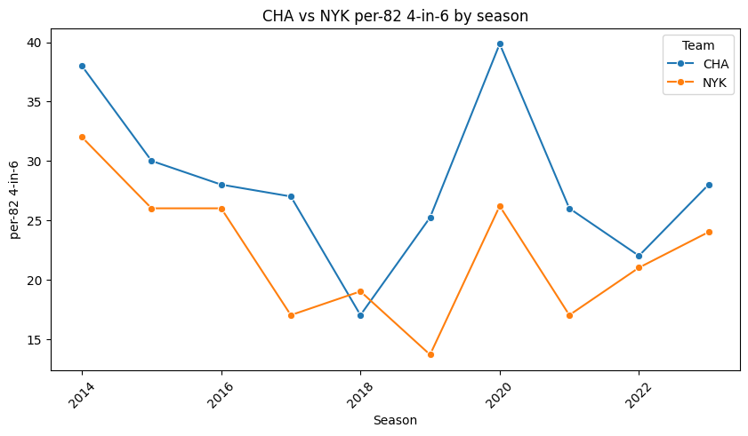

```python
import matplotlib.pyplot as plt
import seaborn as sns

# Step 1: CHA vs NYK
plt.figure(figsize=(10,5))
sns.lineplot(data = df_team_x_in_y[df_team_x_in_y["team"].isin(["CHA", "NYK"])],
             x = "season", y = "x_in_y_per_82", hue = "team", marker = "o")
plt.title("CHA vs NYK per-82 4-in-6 by season")
plt.ylabel("per-82 4-in-6")
plt.xlabel("Season")
plt.xticks(rotation=45)
plt.legend(title="Team")
plt.show()
```

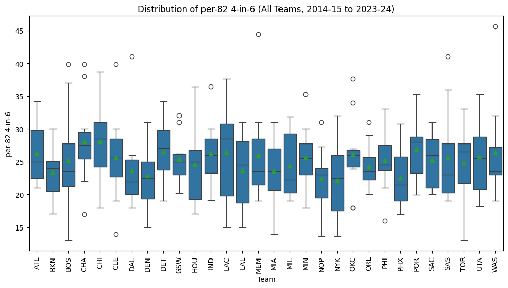

```python
# Step 2: All 30 teams boxplot
plt.figure(figsize = (12, 6))
sns.boxplot(data = df_team_x_in_y, x = "team", y = "x_in_y_per_82", showmeans = True)
plt.title("Distribution of per-82 4-in-6 (All Teams, 2014-15 to 2023-24)")
plt.ylabel("per-82 4-in-6")
plt.xlabel("Team")
plt.xticks(rotation = 90)
plt.show()
```

```python
# Step 3: Permutation Test (Resampling)
'''
My strategy is to to randomly reassign the seasonal 4-in-6 counts across teams in each season,
so that over 10 seasons each team is treated as if its schedule difficulty were randomly drawn from the pool of all teams.
This simulates the null hypothesis that there is no inherent "team effect" in 4-in-6 frequency.
By repeating this process many times,
I then generate the distribution of the max–min gap expected by chance,
and can then compare the observed gap to this null distribution to assess significance.
'''
import numpy as np
import pandas as pd

def permute_by_season_maxmin_gap(df_team_x_in_y: pd.DataFrame, n_iter: int = 100000, ci: float = 0.95, random_state: int = 405):

    rng = np.random.default_rng(random_state)

    # Observed max min gap (Which is AVG(CHA) - AVG(NYK) from Q3)
    team_means_obs = df_team_x_in_y.groupby("team")["x_in_y_per_82"].mean()
    observed_gap = float(team_means_obs.max() - team_means_obs.min())

    teams = sorted(df_team_x_in_y["team"].unique())
    seasons = sorted(df_team_x_in_y["season"].unique())

    # List the values of x in y per 82 by teams in each season
    season_x_in_y_per_82_by_teams = {}

    for season in seasons:

        season_x_in_y_per_82_by_teams[season] = df_team_x_in_y.loc[df_team_x_in_y["season"] == season,
                                                                   "x_in_y_per_82"].to_numpy()
    permutation_gaps = np.empty(n_iter, dtype=float)

    for i in range(n_iter):
        assign = {}

        for team in teams:
            assign[team] = []

        # Shuffle values of x_in_y_per_82 to teams
        for season in seasons:

            values_x_in_y_per_82 = season_x_in_y_per_82_by_teams[season]
            # Randomly permute the value in the season, and link with team list
            permuted_values = rng.permutation(values_x_in_y_per_82)

            for team, value in zip(teams, permuted_values):
                assign[team].append(value)

        # Calculate each teams' avg 4-in-6 in 10 season and find the max-min gap
        means = []
        for team in teams:
            permuted_avg_4_in_6_per_team = np.mean(assign[team])
            means.append(permuted_avg_4_in_6_per_team)

        permutation_gaps[i] = float(max(means) - min(means))

    # Percentile CI and p-value
    alpha = 1 - ci
    ci_lo, ci_hi = np.quantile(permutation_gaps, [alpha/2, 1 - alpha/2])
    p_value = (np.sum(permutation_gaps >= observed_gap) + 1) / (n_iter + 1)

    return observed_gap, (ci_lo, ci_hi), p_value, permutation_gaps

n_iter = 20000
observed_gap, (ci_lo, ci_hi), p_value, permutation_gaps = permute_by_season_maxmin_gap(
                                                          df_team_x_in_y, n_iter = n_iter, ci = 0.95, random_state = 405
                                                          )

print(f"Permutation {n_iter:,} (by-season, 10 year max-min gap)")
print(f"Observed gap = {observed_gap:.3f}")
print(f"95% percentile CI = [{ci_lo:.3f}, {ci_hi:.3f}]")
print(f"Right tail p-value = {p_value:.4f}")
```

```
Permutation 20,000 (by-season, 10 year max-min gap)
Observed gap = 5.923
95% percentile CI = [3.381, 6.325]
Right tail p-value = 0.0661
```

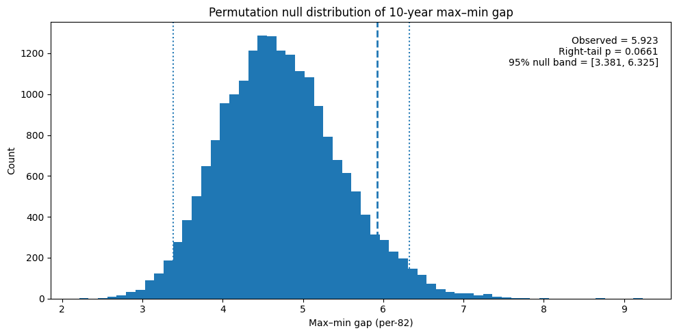

```python
plt.figure(figsize=(10,5))
plt.hist(permutation_gaps, bins=60)
plt.axvline(observed_gap, linestyle = "--", linewidth = 2)
plt.axvline(ci_lo, linestyle = ":")
plt.axvline(ci_hi, linestyle = ":")
plt.title("Permutation null distribution of 10-year max–min gap")
plt.xlabel("Max–min gap (per-82)")
plt.ylabel("Count")

plt.text(0.98, 0.95,
         f"Observed = {observed_gap:.3f}\nRight-tail p = {p_value:.4f}\n95% null band = [{ci_lo:.3f}, {ci_hi:.3f}]",
         ha="right", va="top", transform=plt.gca().transAxes)
plt.tight_layout()
plt.show()
```

**ANSWER 4:**

### Line Chart & Boxplot Interpretation

Line Chart: CHA is above NYK in nearly every season, suggesting a persistent directional gap.

Boxplot: Distributions overlap substantially and exhibit sizable season-level variation. Even teams with higher means (e.g., CHA/CHI) and lower means (e.g., NYK) are in a fairly wide league spread, which is why I followed up with a season-stratified permutation test.

### Permutation Test

I addressed Q4 as an extremes problem: "Is the league’s 10-year max min gap unusually large?"

Within each season, I reshuffled that season’s 30 team values across team labels (preserving season difficulty), recompute 10-year team means, and take the max–min gap. Repeating this many times yields the null distribution where team labels carry no effect.

The result showed:

The directional pattern (CHA > NYK most seasons) is real in this sample, but once we frame Q4 correctly as a “most vs least across 30 teams” question and account for choosing extremes after seeing all teams, the gap is explained by season-level variability rather than a strong, persistent team effect.

### Question 5

**QUESTION:** What was BKN's defensive eFG% in the 2023-24 season? What was their defensive eFG% that season in situations where their opponent was on the second night of back-to-back?

```python
# eFG% = (fgmade + (0.5 * fg3made))/fgattempted

# team_game_data.csv only has off teams' stats
# need to use BKN as def_team

game_data_2023 = game_data[game_data["season"] == 2023].copy()
game_data_2023_BKN_def = game_data_2023[game_data_2023["def_team"] == "BKN"].copy()
game_data_2023_BKN_def_season = game_data_2023_BKN_def[game_data_2023_BKN_def["gametype"] == 2].copy()


BKN_def_eFG_2023_season = (
    game_data_2023_BKN_def_season["fgmade"].sum()
    + 0.5 * game_data_2023_BKN_def_season["fg3made"].sum()
    )/ game_data_2023_BKN_def_season["fgattempted"].sum()

print(f"BKN's defensive eFG%: {BKN_def_eFG_2023_season:.3f}")
```

```
BKN's defensive eFG%: 0.543
```

```python
# When opponent on a B2B
season_schedule_2023 = schedule[schedule["season"] == 2023].copy()

game_data_2023_BKN_def_season["gamedate"] = pd.to_datetime(game_data_2023_BKN_def_season["gamedate"], errors="coerce")

def bkn_def_efg_if_opp_b2b(season_schedule: pd.DataFrame = season_schedule_2023,
                     game_data_2023_BKN_def_season: pd.DataFrame = game_data_2023_BKN_def_season,
                     target_team: str = "BKN"):

    team_schedule = season_schedule[season_schedule["team"] == target_team].copy()
    team_schedule = team_schedule.sort_values("gamedate").reset_index(drop=True)

    game_data_2023_BKN_def_season = game_data_2023_BKN_def_season.copy()
    game_data_2023_BKN_def_season["B2B"] = 0

    for game_night, opponent in team_schedule[["gamedate", "opponent"]].itertuples(index = False, name = None):

        night_before = game_night - pd.Timedelta(days = 1)

        opp_had_game_prev_night = (season_schedule[(season_schedule["team"] == opponent)
                                                  & (season_schedule["gamedate"] == night_before)
                                                  ].shape[0] > 0
                                   )

        if opp_had_game_prev_night:
            game_data_2023_BKN_def_season.loc[(
                (game_data_2023_BKN_def_season["gamedate"] == game_night) &
                (game_data_2023_BKN_def_season["off_team"] == opponent) &
                (game_data_2023_BKN_def_season["def_team"] == "BKN")), "B2B"] = 1

    game_data_2023_BKN_def_season_opp_b2b = game_data_2023_BKN_def_season[game_data_2023_BKN_def_season["B2B"] == 1]

    BKN_def_eFG_2023_season_opp_b2b = (
        game_data_2023_BKN_def_season_opp_b2b["fgmade"].sum()
        + 0.5 * game_data_2023_BKN_def_season_opp_b2b["fg3made"].sum()
        )/ game_data_2023_BKN_def_season_opp_b2b["fgattempted"].sum()

    return BKN_def_eFG_2023_season_opp_b2b

BKN_def_eFG_2023_season_opp_b2b = bkn_def_efg_if_opp_b2b(season_schedule = season_schedule_2023,
                                                   game_data_2023_BKN_def_season = game_data_2023_BKN_def_season,
                                                   target_team = "BKN")

print(f"When opponent on a B2B: {BKN_def_eFG_2023_season_opp_b2b:.3f}")
```

```
When opponent on a B2B: 0.535
```

**ANSWER 5:**

- BKN Defensive eFG%: 54.3%
- When opponent on a B2B: 53.5%

## Part 2 -- Trends and Visualizations

This is an intentionally open ended section, and there are multiple approaches you could take to have a successful project. Feel free to be creative. However, for this section, please consider only the density of games and travel schedule, not the relative on-court strength of different teams.

### Question 6

**QUESTION:** Please identify at least 2 trends in scheduling over time. In other words, how are the more recent schedules different from the schedules of the past? Please include a visual (plot or styled table) highlighting or explaining each trend and include a brief written description of your findings.

#### 6-1 Consider only Rest & Schedule Density

```python
def add_rest_days(schedule: pd.DataFrame) -> pd.DataFrame:

    schedule_rests = schedule.copy()
    team_x_in_y = []

    schedule_rests = schedule_rests.sort_values(["team", "season", "gamedate"]).reset_index(drop=True)

    schedule_rests["prev_gamedate"] = schedule_rests.groupby(["team", "season"])["gamedate"].shift(1)
    schedule_rests["days_diff_between_games"] = (schedule_rests["gamedate"] - schedule_rests["prev_gamedate"]).dt.days
    schedule_rests["rest_days"] = schedule_rests["days_diff_between_games"] - 1
    schedule_rests = schedule_rests.drop(columns=["prev_gamedate", "days_diff_between_games"])

    schedule_rests["is_b2b"] = (schedule_rests["rest_days"] == 0).astype(int)

    return schedule_rests

schedule_rests = add_rest_days(schedule)
schedule_rests.head(3)
```

|  | season | gamedate | team | opponent | home | win | rest_days | is_b2b |
| --- | --- | --- | --- | --- | --- | --- | --- | --- |
| 0 | 2014 | 2014-10-29 | ATL | TOR | 0 | 0 | NaN | 0 |
| 1 | 2014 | 2014-11-01 | ATL | IND | 1 | 1 | 2.0 | 0 |
| 2 | 2014 | 2014-11-05 | ATL | SAS | 0 | 0 | 3.0 | 0 |

```python
def league_rest_trends(schedule_rests: pd.DataFrame) -> pd.DataFrame:

    schedule_rests = schedule_rests.copy()
    schedule_rests.dropna(subset=["rest_days"], inplace=True) # No records of rest days

    team_season = schedule_rests.groupby(["season", "team"]).agg(
        avg_rest_days = ("rest_days", "mean"),
        b2b_games = ("is_b2b", "sum"),
        total_games = ("gamedate", "count")
    ).reset_index()
    team_season["b2b_rate"] = team_season["b2b_games"] / team_season["total_games"]

    league_season = team_season.groupby("season").agg(
        league_avg_rest_days = ("avg_rest_days", "mean"),
        league_avg_b2b_rate = ("b2b_rate", "mean")
    ).reset_index()

    return league_season

league_trends = league_rest_trends(schedule_rests)
league_trends
```

|  | season | league_avg_rest_days | league_avg_b2b_rate |
| --- | --- | --- | --- |
| 0 | 2014 | 1.074897 | 0.238683 |
| 1 | 2015 | 1.075720 | 0.219753 |
| 2 | 2016 | 1.074074 | 0.202058 |
| 3 | 2017 | 1.157202 | 0.178189 |
| 4 | 2018 | 1.157202 | 0.163786 |
| 5 | 2019 | 2.607710 | 0.150909 |
| 6 | 2020 | 1.027230 | 0.214554 |
| 7 | 2021 | 1.123457 | 0.174074 |
| 8 | 2022 | 1.124280 | 0.165021 |
| 9 | 2023 | 1.124280 | 0.173663 |

```python
# The below functions are from functions I created in Q2 and Q4
# I put it here for reference
def team_games_by_season(schedule: pd.DataFrame):

    team_games_by_season = (schedule
                            .groupby(["season", "team"], as_index=False)["gamedate"].count()
                            .rename(columns={"gamedate": "games"})
                            .sort_values(["season", "team"])
                            .reset_index(drop=True)
                            )

    return team_games_by_season

team_x_season = team_games_by_season(schedule)

def each_team_x_in_y_season(schedule: pd.DataFrame, team_x_season: pd.DataFrame, x: int = 4, y: int = 6)-> pd.DataFrame:

    schedule = schedule.copy()
    team_x_in_y = []

    for team in sorted(team_x_season["team"].unique()):

        for season in team_x_season[team_x_season["team"] == team]["season"]:

            season_schedule = schedule[schedule["season"] == season].copy()
            season_schedule = season_schedule.sort_values("gamedate").reset_index(drop=True)

            team_games_in_season = team_x_season[(team_x_season["season"] == season)
                                                & (team_x_season["team"] == team)]["games"].iloc[0]

            team_4_in_6 = count_x_in_y_v2(schedule = season_schedule, team = team, x = x, y = y)
            team_4_in_6_per_82 = team_4_in_6 * 82 / team_games_in_season

            team_x_in_y.append({"team": team, "season": season,"x_in_y_per_82": team_4_in_6_per_82})

    df_team_x_in_y = pd.DataFrame(team_x_in_y)

    return df_team_x_in_y
```

```python
def _league_trend_from_team_level(team_level_df: pd.DataFrame, label: str) -> pd.DataFrame:

    league = (team_level_df
              .groupby("season", as_index=False)
              .agg(league_mean=("x_in_y_per_82", "mean")))

    league["metric"] = label

    return league

schedule_3_in_4 = each_team_x_in_y_season(schedule, team_x_season, x = 3, y = 4)
schedule_3_in_5 = each_team_x_in_y_season(schedule, team_x_season, x = 3, y = 5)
schedule_4_in_5 = each_team_x_in_y_season(schedule, team_x_season, x = 4, y = 5)
schedule_4_in_6 = each_team_x_in_y_season(schedule, team_x_season, x = 4, y = 6)
schedule_5_in_6 = each_team_x_in_y_season(schedule, team_x_season, x = 5, y = 6)
schedule_5_in_7 = each_team_x_in_y_season(schedule, team_x_season, x = 5, y = 7)

league_3_in_4 = _league_trend_from_team_level(schedule_3_in_4, "3-in-4")
league_3_in_5 = _league_trend_from_team_level(schedule_3_in_5, "3-in-5")
league_4_in_5 = _league_trend_from_team_level(schedule_4_in_5, "4-in-5")
league_4_in_6 = _league_trend_from_team_level(schedule_4_in_6, "4-in-6")
league_5_in_6 = _league_trend_from_team_level(schedule_5_in_6, "5-in-6")
league_5_in_7 = _league_trend_from_team_level(schedule_5_in_7, "5-in-7")

league_x_in_y = pd.concat([league_3_in_4,
                           league_3_in_5,
                           league_4_in_5,
                           league_4_in_6,
                           league_5_in_6,
                           league_5_in_7], ignore_index=True)
league_x_in_y.head(3)
```

|  | season | league_mean | metric |
| --- | --- | --- | --- |
| 0 | 2014 | 26.733333 | 3-in-4 |
| 1 | 2015 | 24.566667 | 3-in-4 |
| 2 | 2016 | 23.933333 | 3-in-4 |

#### 6-2 Consecutive Homes/Aways

```python
def get_venue(schedule: pd.DataFrame, locations: pd.DataFrame) -> pd.DataFrame:

    schedule_x_location = schedule.copy()
    schedule_x_location["home"] = schedule_x_location["home"].astype(int)

    # Determine Venue (home == 1 -> team; home = =0 -> opponent)
    schedule_x_location["venue_team"] = np.where(schedule_x_location["home"].eq(1),
                                                 schedule_x_location["team"],
                                                 schedule_x_location["opponent"])

    # rename loc to for better understanding column names
    locations = locations.rename(columns={
        "team": "venue_team",
        "latitude": "venue_latitude",
        "longitude": "venue_longitude",
        "timezone": "venue_timezone"
    })

    schedule_x_location = schedule_x_location.merge(locations,
                                                    on="venue_team",
                                                    how="left")

    return schedule_x_location

schedule_x_location = get_venue(schedule, locations)
schedule_x_location.head(3)
```

|  | season | gamedate | team | opponent | home | win | venue_team | venue_latitude | venue_longitude | venue_timezone |
| --- | --- | --- | --- | --- | --- | --- | --- | --- | --- | --- |
| 0 | 2014 | 2015-04-15 | SAC | LAL | 0 | 1 | LAL | 34.043006 | -118.267360 | Pacific |
| 1 | 2014 | 2015-04-15 | NYK | DET | 1 | 0 | NYK | 40.750562 | -73.993471 | Eastern |
| 2 | 2014 | 2015-04-15 | DEN | GSW | 0 | 0 | GSW | 37.767927 | -122.387326 | Pacific |

```python
venues = (schedule_x_location[["venue_team", "venue_latitude", "venue_longitude"]]
          .drop_duplicates(subset=["venue_team"])
          .reset_index(drop=True))

# Haversine Formula (Recommended by ChatGPT)
def haversine_km(lat1, lon1, lat2, lon2):

    R = 6371.0
    lat1 = np.radians(lat1); lon1 = np.radians(lon1)
    lat2 = np.radians(lat2); lon2 = np.radians(lon2)
    dlat = lat2 - lat1
    dlon = lon2 - lon1
    a = np.sin(dlat/2.0)**2 + np.cos(lat1)*np.cos(lat2)*np.sin(dlon/2.0)**2
    c = 2*np.arcsin(np.sqrt(a))

    return R * c

teams = sorted(venues["venue_team"].unique())
distances = []

for team_1 in teams:
    lat1, lon1 = venues.loc[venues["venue_team"] == team_1, ["venue_latitude","venue_longitude"]].values[0]
    for team_2 in teams:
        lat2, lon2 = venues.loc[venues["venue_team"] == team_2, ["venue_latitude","venue_longitude"]].values[0]
        dist_km = float(haversine_km(lat1, lon1, lat2, lon2))
        distances.append({"venue_team_A": team_1, "venue_team_B": team_2, "dist_km": dist_km})

venue_distance = pd.DataFrame(distances)
venue_distance.head(3)
```

|  | venue_team_A | venue_team_B | dist_km |
| --- | --- | --- | --- |
| 0 | ATL | ATL | 0.000000 |
| 1 | ATL | BKN | 1200.326711 |
| 2 | ATL | BOS | 1506.503719 |

```python
tz_map = {"Pacific": 0, "Mountain": 1, "Central": 2, "Eastern": 3}
schedule_x_location["venue_tz_code"] = schedule_x_location["venue_timezone"].map(tz_map)

schedule_travel = (schedule_x_location
                   .sort_values(["team", "season", "gamedate"])
                   .reset_index(drop=True)
                  )

schedule_travel["prev_venue_team"] = schedule_travel.groupby(["team", "season"])["venue_team"].shift(1)
schedule_travel["prev_venue_timezone"] = schedule_travel.groupby(["team", "season"])["venue_timezone"].shift(1)
schedule_travel["prev_venue_tz_code"] = schedule_travel.groupby(["team", "season"])["venue_tz_code"].shift(1)

schedule_travel["tz_delta"] = schedule_travel["venue_tz_code"] - schedule_travel["prev_venue_tz_code"]
schedule_travel["cross_timezone"] = schedule_travel["tz_delta"].fillna(0).ne(0).astype(int)

#Merge venue distance to schedule
venue_distance_for_join = venue_distance.rename(columns={
    "venue_team_A": "prev_venue_team",
    "venue_team_B": "venue_team",
    "dist_km": "travel_dist_km"
})

schedule_travel = schedule_travel.merge(
    venue_distance_for_join,
    on=["prev_venue_team", "venue_team"],
    how="left"
)

schedule_travel.head(3)
```

|  | season | gamedate | team | opponent | home | win | venue_team | venue_latitude | venue_longitude | venue_timezone | venue_tz_code | prev_venue_team | prev_venue_timezone | prev_venue_tz_code | tz_delta | cross_timezone | travel_dist_km |
| --- | --- | --- | --- | --- | --- | --- | --- | --- | --- | --- | --- | --- | --- | --- | --- | --- | --- |
| 0 | 2014 | 2014-10-29 | ATL | TOR | 0 | 0 | TOR | 43.643521 | -79.379082 | Eastern | 3 | NaN | NaN | NaN | NaN | 0 | NaN |
| 1 | 2014 | 2014-11-01 | ATL | IND | 1 | 1 | ATL | 33.757233 | -84.396340 | Eastern | 3 | TOR | Eastern | 3.0 | 0.0 | 0 | 1181.784420 |
| 2 | 2014 | 2014-11-05 | ATL | SAS | 0 | 0 | SAS | 29.427002 | -98.437482 | Central | 2 | ATL | Eastern | 3.0 | -1.0 | 1 | 1412.898903 |

```python
schedule_travel["home_shift"] = schedule_travel.groupby(["team", "season"])["home"].shift(1)

# if home to away or away to homw -> segment break
schedule_travel["segment_break"] = (schedule_travel["home"] != schedule_travel["home_shift"]).fillna(True)

# accum sum of segment_break → segment_id
schedule_travel["segment_id"] = schedule_travel.groupby(["team", "season"])["segment_break"].cumsum().astype(int)

schedule_travel["segment_type"] = np.where(schedule_travel["home"] == 1, "home_stand", "road_trip")

segment_len = (schedule_travel
               .groupby(["team","season","segment_id","segment_type"], as_index=False)
               .agg(segment_len = ("gamedate", "count")))

# consecutive home/away: segement length >= 2
segment_len_over_2d = segment_len.query("segment_len >= 2").copy()
segment_len_over_2d.head()

schedule_travel = schedule_travel.merge(
    segment_len[["team","season","segment_id","segment_len","segment_type"]],
    on=["team","season","segment_id","segment_type"],
    how="left",
    validate="m:1"
)

schedule_travel["in_home_stand_over_2d"] = ((schedule_travel["segment_type"] == "home_stand") &
                                       (schedule_travel["segment_len"] >= 2)).astype(int)
schedule_travel["in_road_trip_over_2d"]  = ((schedule_travel["segment_type"] == "road_trip") &
                                       (schedule_travel["segment_len"] >= 2)).astype(int)

league_homeroad_share = (schedule_travel
    .groupby(["season"], as_index=False)
    .agg(
        games_total = ("gamedate", "count"),
        games_in_home_stand_over_2d = ("in_home_stand_over_2d","sum"),
        games_in_road_trip_over_2d = ("in_road_trip_over_2d","sum"),
    ))

league_homeroad_share["pct_home_stand_over_2d"] = league_homeroad_share["games_in_home_stand_over_2d"] / league_homeroad_share["games_total"]
league_homeroad_share["pct_road_trip_over_2d"]  = league_homeroad_share["games_in_road_trip_over_2d"]  / league_homeroad_share["games_total"]

league_homeroad_share = league_homeroad_share.sort_values("season").reset_index(drop=True)
league_homeroad_share.head()


# team avg consecutive home/away (at least 2 games)
team_season_seg = (segment_len_over_2d
                   .groupby(["team","season","segment_type"], as_index=False)
                   .agg(avg_seg_len=("segment_len", "mean"),
                        max_seg_len=("segment_len", "max")))

# league avg consecutive home/away (at least 2 games)
league_seg = (team_season_seg
              .groupby(["season","segment_type"], as_index=False)
              .agg(league_avg_seg_len=("avg_seg_len", "mean"),
                   league_max_seg_len=("max_seg_len", "mean")))

league_seg.head(3)
```

|  | season | segment_type | league_avg_seg_len | league_max_seg_len |
| --- | --- | --- | --- | --- |
| 0 | 2014 | home_stand | 2.990796 | 5.466667 |
| 1 | 2014 | road_trip | 3.026148 | 5.600000 |
| 2 | 2015 | home_stand | 2.959172 | 5.766667 |

#### Consider Rest + Travel

```python
schedule_rest_n_travel = pd.merge(
    schedule_rests,
    schedule_travel,
    on=["season", "gamedate", "team", "opponent", "home", "win"],
    how="inner",
    validate="1:1"
)


# AVG( rest day : B2B )
rest_summary = (schedule_rest_n_travel
    .groupby(["season", "team"], as_index=False)
    .agg(avg_rest_days=("rest_days", "mean"),
         b2b_games=("is_b2b", "sum"),
         total_games=("gamedate", "count"))
)
rest_summary["b2b_rate"] = rest_summary["b2b_games"] / rest_summary["total_games"]

league_rest_summary = (rest_summary
    .groupby("season", as_index=False)
    .agg(league_avg_rest_days = ("avg_rest_days", "mean"),
         league_avg_b2b_rate = ("b2b_rate", "mean"))
)

# Diff rest_days vs Travel Distance & Time Zone
# (bin use -1~100 to contain number like 0 and 4+ )
schedule_rest_n_travel["rest_bin"] = pd.cut(
    schedule_rest_n_travel["rest_days"],
    bins = [-1, 0, 1, 2, 3, 100],
    labels = ["0", "1", "2", "3", "4+"]
)
schedule_rest_n_travel["cross_timezone"] = schedule_rest_n_travel["tz_delta"].fillna(0).ne(0).astype(int)

rest_travel = (schedule_rest_n_travel
    .dropna(subset = ["rest_bin"])
    .groupby(["season", "rest_bin"], as_index = False)
    .agg(
        games = ("gamedate", "count"),
        mean_dist_km = ("travel_dist_km", "mean"),
        pct_cross_tz = ("cross_timezone", "mean")
    )
)
```

**ANSWER 6:**

#### Overall

The league made steady progress in reducing schedule compression and B2Bs up to 2018. After COVID, rest days fell slightly, and both B2B% and dense stretches (3-in-4, 4-in-6) rose again. Homestands and road trips also became longer: this lowers the number of travel transitions, but it also means longer continuous stretches away from home. The only consistent travel adjustment is that B2Bs are scheduled with shorter distances and fewer cross-time-zone trips.

(Note: 2019 season & 2020 season is not included in the discussion as both season were affected by Covid19.)

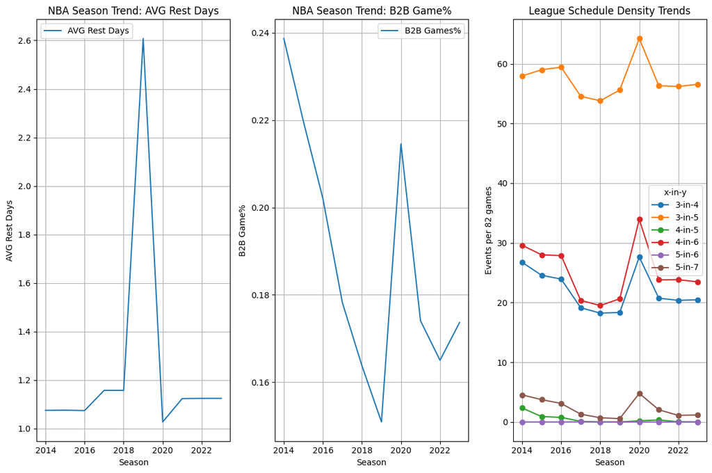

```python
fig, axes = plt.subplots(1, 3, figsize=(12, 8))

# Plot 1: Avg Rest Days
axes[0].plot(league_trends["season"], league_trends["league_avg_rest_days"], label="AVG Rest Days")
axes[0].set_title("NBA Season Trend: AVG Rest Days")
axes[0].set_xlabel("Season")
axes[0].set_ylabel("AVG Rest Days")
axes[0].legend()
axes[0].grid(True)

# Plot 2: B2B Games%
axes[1].plot(league_trends["season"], league_trends["league_avg_b2b_rate"], label="B2B Games%")
axes[1].set_title("NBA Season Trend: B2B Game%")
axes[1].set_xlabel("Season")
axes[1].set_ylabel("B2B Game%")
axes[1].legend()
axes[1].grid(True)

# Plot 3: Schedule Density (x-in-y)
pivot = (league_x_in_y
         .pivot(index="season", columns="metric", values="league_mean")
         .sort_index()
        )

for col in pivot.columns:
    axes[2].plot(pivot.index, pivot[col], marker="o", label=col)

axes[2].set_title("League Schedule Density Trends")
axes[2].set_xlabel("Season")
axes[2].set_ylabel("Events per 82 games")
axes[2].legend(title="x-in-y")
axes[2].grid(True)

plt.tight_layout()
plt.show()
```

#### 6-1 Consider Rest Days and Back-to-Back Games

For average rest days, the trend looks flat overall, but COVID seasons (2019, 2020) distort the data. In 2019 the pause gave teams more rest, while in 2020 the delayed start compressed the schedule. Excluding those years, average rest rose from about 1.07 days (2014–16) to 1.16 (2017–18), then settled slightly lower at ~1.12 (2021–23).

For back-to-back (B2B) games, the share steadily dropped from 2014 to 2018. The COVID seasons again break the pattern. Since 2021, B2B% has been higher than in 2018, though still below early levels.

For schedule density, the most common cases (3-in-4, 3-in-5, 4-in-6) show the same pattern as B2B%. They declined through 2018, spiked during COVID disruptions, and have been a bit higher again since 2021 compared to 2018.

Overall, the league reduced schedule compression up to 2018, but some of the progress has reversed after COVID.

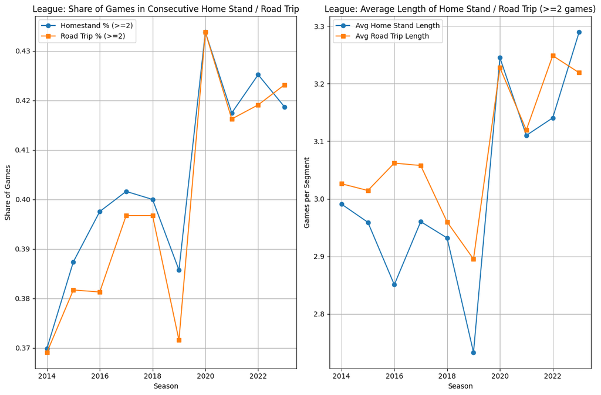

```python
import matplotlib.pyplot as plt

fig, axes = plt.subplots(1, 2, figsize=(12, 8))

# --- Plot 1: Share of games in homestand / road trip ---
axes[0].plot(
    league_homeroad_share["season"],
    league_homeroad_share["pct_home_stand_over_2d"],
    marker="o", label="Homestand % (>=2)"
)
axes[0].plot(
    league_homeroad_share["season"],
    league_homeroad_share["pct_road_trip_over_2d"],
    marker="s", label="Road Trip % (>=2)"
)
axes[0].set_title("League: Share of Games in Consecutive Home Stand / Road Trip")
axes[0].set_xlabel("Season")
axes[0].set_ylabel("Share of Games")
axes[0].grid(True)
axes[0].legend()

# Plot 2: Average length of home stand / road trip
for seg_type, label, marker in [
    ("home_stand", "Avg Home Stand Length", "o"),
    ("road_trip", "Avg Road Trip Length", "s")
]:
    subset = league_seg[league_seg["segment_type"] == seg_type]
    axes[1].plot(
        subset["season"], subset["league_avg_seg_len"],
        marker=marker, label=label
    )

axes[1].set_title("League: Average Length of Home Stand / Road Trip (>=2 games)")
axes[1].set_xlabel("Season")
axes[1].set_ylabel("Games per Segment")
axes[1].grid(True)
axes[1].legend()

plt.tight_layout()
plt.show()
```

#### 6-2 Home Stands and Road Trips

Ignoring 2019 and 2020 because of COVID disruptions, we see a clear trend: the share of games that are part of a homestand (≥2 games) or a road trip (≥2 games) has gone up in recent years.

In short, consecutive home and road stretches are happening more often and lasting longer than before.

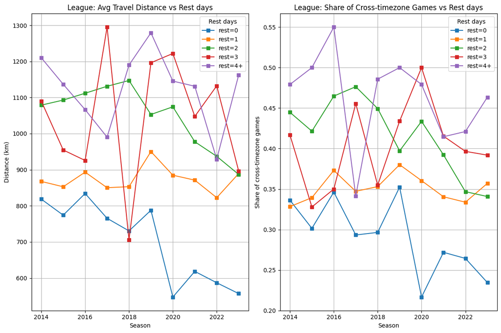

```python
fig, axes = plt.subplots(1, 2, figsize=(12, 8))

# Plot 1: Travel distance vs Rest days
pivot_rest_dist = rest_travel.pivot(
    index="season", columns="rest_bin", values="mean_dist_km"
).sort_index()

for col in pivot_rest_dist.columns:
    axes[0].plot(pivot_rest_dist.index, pivot_rest_dist[col], marker="s", label=f"rest={col}")

axes[0].set_title("League: Avg Travel Distance vs Rest days")
axes[0].set_xlabel("Season")
axes[0].set_ylabel("Distance (km)")
axes[0].grid(True)
axes[0].legend(title="Rest days")

# Plot 2: Cross-timezone share vs Rest days
pivot_rest_tz = rest_travel.pivot(
    index="season", columns="rest_bin", values="pct_cross_tz"
).sort_index()

for col in pivot_rest_tz.columns:
    axes[1].plot(pivot_rest_tz.index, pivot_rest_tz[col], marker="s", label=f"rest={col}")

axes[1].set_title("League: Share of Cross-timezone Games vs Rest days")
axes[1].set_xlabel("Season")
axes[1].set_ylabel("Share of cross-timezone games")
axes[1].grid(True)
axes[1].legend(title="Rest days")

plt.tight_layout()
plt.show()
```

#### 6-3 Travel Distance and Rest Days

Looking at travel distance by rest days, the main pattern is for back-to-backs (rest = 0). These games clearly have shorter travel and fewer cross-timezone trips. This makes sense, since the league usually schedules B2Bs with minimal travel to reduce stress.

For games with 1 day and 3 or more rest, there is no clear or stable pattern. The distances and cross-timezone shares fluctuate across years, without a consistent trend.

Surprisingly, for games with 2 day rest, the games first had increasing travel distance during 2014-2018, but then had decreasing travel since 2021. (2019 & 2020 excluded)

### Question 7

**QUESTION:** Please design a plotting tool to help visualize a team’s schedule for a season. The plot should cover the whole season and should help the viewer contextualize and understand a team’s schedule, potentially highlighting periods of excessive travel, dense blocks of games, or other schedule anomalies. If you can, making the plots interactive (for example through the plotly package) is a bonus.

Please use this tool to plot OKC and DEN's provided 80-game 2024-25 schedules.

```python
def compute_travel_with_table(df: pd.DataFrame, locs: pd.DataFrame, venue_distance: pd.DataFrame) -> pd.DataFrame:

    x = get_venue(df, locs).sort_values(["team","season","gamedate"]).reset_index(drop=True)
    x["prev_venue_team"] = x.groupby(["team","season"])["venue_team"].shift(1)

    # Distance: prev_venue_team -> venue_team
    vd = venue_distance.rename(columns={
        "venue_team_A":"prev_venue_team",
        "venue_team_B":"venue_team",
        "dist_km":"travel_km"
    })
    x = x.merge(vd, on=["prev_venue_team","venue_team"], how="left")

    # First Game → 0 km
    x["travel_km"] = x["travel_km"].fillna(0.0)

    # Time Zone
    tz_map = {"Pacific":0,"Mountain":1,"Central":2,"Eastern":3}
    x["venue_tz_code"] = x["venue_timezone"].map(tz_map)
    x["prev_tz_code"] = x.groupby(["team","season"])["venue_tz_code"].shift(1)
    x["tz_delta"] = x["venue_tz_code"] - x["prev_tz_code"]
    x["cross_timezone"] = x["tz_delta"].fillna(0).ne(0).astype(int)
    return x



def add_markers(team_df):
    d = team_df.sort_values("gamedate").copy()
    x1=[]; x2=[]; x3=[]

    for t in d["gamedate"]:

        x1.append(((d["gamedate"] >= t - pd.Timedelta(days=3)) & (d["gamedate"] <= t)).sum())  # 4d
        x2.append(((d["gamedate"] >= t - pd.Timedelta(days=4)) & (d["gamedate"] <= t)).sum())  # 5d
        x3.append(((d["gamedate"] >= t - pd.Timedelta(days=5)) & (d["gamedate"] <= t)).sum())  # 6d

    d["x1_in_4"] = x1; d["x2_in_5"] = x2; d["x3_in_6"] = x3
    d["m1"] = (d["x1_in_4"] == 3)  # ●
    d["m2"] = (d["x2_in_5"] == 3)  # ▲
    d["m3"] = (d["x3_in_6"] == 4)  # ★
    d["markers"] = (np.where(d["m1"], "●", "") + np.where(d["m2"], "▲", "") + np.where(d["m3"], "★", ""))

    # Show：3-in-4 / 3-in-5 / 4-in-6
    badge_list = []
    for a,b,c in zip(d["m1"], d["m2"], d["m3"]):
        tags = []
        if a: tags.append("3-in-4")
        if b: tags.append("3-in-5")
        if c: tags.append("4-in-6")
        badge_list.append(" / ".join(tags))
    d["badges"] = badge_list
    return d
```

```python
# Build data for HTML (no HTML yet)

from pathlib import Path
import json
import calendar

TARGET_TEAMS = ["OKC", "DEN"]
TARGET_SEASON = 2024

# 1. Calendar Sou：partial OKC/DEN 2024-25
draft_schedule_calendar = (
    draft_schedule
      .assign(
          gamedate = lambda d: d["gamedate"],
          team = lambda d: d["team"].str.upper(),
          opponent = lambda d: d["opponent"].str.upper()
      )
      .query("season == @TARGET_SEASON and team in @TARGET_TEAMS")
      .sort_values(["team","gamedate"])
      .reset_index(drop=True)
)

# 2. Travel Distance Quantile based on historical league-wide (schedule.csv) + locations
venue_distance[["venue_team_A","venue_team_B"]] = venue_distance[["venue_team_A","venue_team_B"]].apply(lambda s: s.str.upper())
league_hist = add_rest_days(schedule.copy().assign(
    team=lambda d: d["team"].str.upper(),
    opponent=lambda d: d["opponent"].str.upper(),
    gamedate=lambda d: pd.to_datetime(d["gamedate"], errors="coerce"),
))
league_hist_travel = compute_travel_with_table(league_hist, locations, venue_distance)

_dist_all = league_hist_travel["travel_km"].dropna()
_dist_all = _dist_all[_dist_all > 0]
Q_NEAR = float(_dist_all.quantile(1/3)) if len(_dist_all) >= 5 else 800.0
Q_FAR  = float(_dist_all.quantile(2/3)) if len(_dist_all) >= 5 else 1800.0
print(f"bins near<{Q_NEAR:.0f}, mid<{Q_FAR:.0f}, far≥{Q_FAR:.0f}")

# 3) Compute OKC/DEN rest/travel on partial & add markers
league_with_rest = add_rest_days(draft_schedule_calendar)
league_travel = compute_travel_with_table(league_with_rest, locations, venue_distance)
print("league_travel rows:", len(league_travel))

marked = []
for tm, tdf in league_travel.groupby("team", sort=False):
    marked.append(add_markers(tdf))
league_ready = pd.concat(marked, ignore_index=True)
print("league_ready rows:", len(league_ready))


# ---- Build JSON-able structures ----
team_data = {}
months_by_team = {}

for team in TARGET_TEAMS:
    t = league_ready[league_ready["team"] == team].sort_values("gamedate").copy()
    t["date"] = t["gamedate"].dt.date.astype(str)

    recs = [{
        "date": r["date"],
        "opponent": str(r["opponent"]),
        "is_home": bool(int(r["home"]) == 1),
        "our_rest": None if pd.isna(r.get("rest_days")) else int(r["rest_days"]),
        "travel_km": 0.0 if pd.isna(r.get("travel_km")) else float(r["travel_km"]),
        "x1_in_4": int(r.get("x1_in_4", 0)),
        "x2_in_5": int(r.get("x2_in_5", 0)),
        "x3_in_6": int(r.get("x3_in_6", 0)),
        "m1": bool(r.get("m1", False)),
        "m2": bool(r.get("m2", False)),
        "m3": bool(r.get("m3", False)),
        "markers": r.get("markers", ""),
        "tz_delta_str": ("+" + str(int(r["tz_delta"])) if r["tz_delta"] > 0 else str(int(r["tz_delta"]))) if not pd.isna(r.get("tz_delta")) else "0",
        "badges": r.get("badges", "")
    } for _, r in t.iterrows()]
    team_data[team] = recs

    ym = sorted({(pd.to_datetime(x["date"]).year, pd.to_datetime(x["date"]).month) for x in recs})
    months_by_team[team] = [
        {"year": y, "month": m, "label": f"{calendar.month_abbr[m]} {y}", "key": f"{y}-{str(m).zfill(2)}"}
        for (y, m) in ym
    ]

print("OKC recs:", len(team_data.get("OKC", [])), "DEN recs:", len(team_data.get("DEN", [])))
print("OKC months:", months_by_team.get("OKC"))
print("DEN months:", months_by_team.get("DEN"))

# 6. Output: JSON (for HTML)
OUT_DIR = Path("./_schedule_dashboard_data")
OUT_DIR.mkdir(parents=True, exist_ok=True)
with open(OUT_DIR / "team_data.json", "w", encoding="utf-8") as f:
    json.dump(team_data, f, ensure_ascii=False)
with open(OUT_DIR / "months_by_team.json", "w", encoding="utf-8") as f:
    json.dump(months_by_team, f, ensure_ascii=False)
with open(OUT_DIR / "meta.json", "w", encoding="utf-8") as f:
    json.dump({"Q_NEAR": Q_NEAR, "Q_FAR": Q_FAR, "teams": TARGET_TEAMS, "season": TARGET_SEASON}, f, ensure_ascii=False)
```

```
bins near<779, mid<1422, far≥1422
league_travel rows: 160
league_ready rows: 160
OKC recs: 80 DEN recs: 80
OKC months: [{'year': 2024, 'month': 10, 'label': 'Oct 2024', 'key': '2024-10'}, {'year': 2024, 'month': 11, 'label': 'Nov 2024', 'key': '2024-11'}, {'year': 2024, 'month': 12, 'label': 'Dec 2024', 'key': '2024-12'}, {'year': 2025, 'month': 1, 'label': 'Jan 2025', 'key': '2025-01'}, {'year': 2025, '…
DEN months: [{'year': 2024, 'month': 10, 'label': 'Oct 2024', 'key': '2024-10'}, {'year': 2024, 'month': 11, 'label': 'Nov 2024', 'key': '2024-11'}, {'year': 2024, 'month': 12, 'label': 'Dec 2024', 'key': '2024-12'}, {'year': 2025, 'month': 1, 'label': 'Jan 2025', 'key': '2025-01'}, {'year': 2025, '…
```

```python
# ================= Part 2: HTML (filters + TZ delta + de-overlap marks) =================
import os, json

OUT_HTML = "Bosan_schedule_dashboard.html"

REST_BG = """
const REST_BG = [
  [0.00, '#fee2e2'], [0.33, '#fee2e2'],  // 0d (red)
  [0.34, '#fef3c7'], [0.66, '#fef3c7'],  // 1d (yellow)
  [0.67, '#dcfce7'], [1.00, '#dcfce7']   // 2+d (green)
];
function restBgValue(n){
  if(n==null) return 0.83;
  if(n>=2)   return 0.83;
  if(n===1)  return 0.50;
  return 0.16;
}
"""

BINS_JS = f"const Q_NEAR={Q_NEAR:.1f}, Q_FAR={Q_FAR:.1f};"

base_html = r"""<!doctype html><html><head><meta charset='utf-8'/>
<title>Schedule Dashboard (v7)</title>
<meta name="viewport" content="width=device-width, initial-scale=1"/>
<style>
  :root { --fg:#111827; --muted:#6b7280; --card:#fff; --border:#e5e7eb;
          --near:#93c5fd; --mid:#60a5fa; --far:#2563eb; }
  body{font-family:Inter,system-ui,-apple-system,Segoe UI,Roboto,Helvetica,Arial,sans-serif;background:#f8fafc;color:var(--fg);margin:0;padding:24px;}
  .row{display:flex;gap:16px;align-items:stretch;flex-wrap:wrap;}
  .col{flex:1;min-width:320px}
  .controls{display:flex;gap:12px;margin-bottom:16px;align-items:center;flex-wrap:wrap}
  .controls select{padding:6px 10px;border-radius:10px;border:1px solid var(--border);background:#fff;}
  .pill{display:inline-flex;gap:8px;align-items:center}
  .card{background:var(--card);border:1px solid var(--border);border-radius:14px;padding:14px 14px 6px 14px;box-shadow:0 2px 10px rgba(0,0,0,.04);}
  #info{font-size:13.5px;margin:6px 2px 10px 2px;color:var(--muted);}
  .legend{margin:8px 2px 0 2px;font-size:12.5px;color:var(--muted);}
  .swatch{display:inline-block;width:10px;height:10px;border-radius:3px;margin:0 6px 0 12px;vertical-align:-1px;}
  label.cb{user-select:none; cursor:pointer; font-size:13px;}
  label.cb input{vertical-align:-2px; margin-right:6px;}
</style>
</head><body>

<div class='controls'>
  <label>Team:
    <select id='teamSel'><option>OKC</option><option>DEN</option></select>
  </label>
  <label>Month:
    <select id='monthSel'></select>
  </label>

  <!-- Filters -->
  <div class="pill">
    <label class="cb"><input type="checkbox" id="f_rest" checked> Rest days</label>
  </div>

  <span style="border-left:1px solid var(--border);height:18px"></span>

  <div class="pill">
    <span>X in Y:</span>
    <label class="cb"><input type="checkbox" id="f_x14" checked> ● 3-in-4</label>
    <label class="cb"><input type="checkbox" id="f_x15" checked> ▲ 3-in-5</label>
    <label class="cb"><input type="checkbox" id="f_x16" checked> ★ 4-in-6</label>
  </div>

  <span style="border-left:1px solid var(--border);height:18px"></span>

  <div class="pill">
    <label class="cb"><input type="checkbox" id="f_tz" checked> Δ Time Zone</label>
  </div>

  <span style="border-left:1px solid var(--border);height:18px"></span>

  <div class="pill">
    <label class="cb"><input type="checkbox" id="f_travel" checked> Travel bars</label>
    <span class='swatch' style='background:var(--near)'></span>near
    <span class='swatch' style='background:var(--mid)'></span>mid
    <span class='swatch' style='background:var(--far)'></span>far
  </div>
</div>

<div class='row'>
  <div class='col card'>
    <div id='calendar' style='height:580px;'></div>
    <div class='legend' id="calLegend">
      Cell = Team rest (0=red, 1=yellow, 2+=green). Markers: ● 3‑in‑4, ▲ 3‑in‑5, ★ 4‑in‑6.
      <br/>Δ Time Zone: 0, +1, −1, ±2
    </div>
    <div id='info'></div>
  </div>
  <div class='col card'>
    <div id='bars' style='height:580px;'></div>
  </div>
</div>

<!-- Inject data from Python -->
<script>
__REST_BG__
const DATA_BY_TEAM = __DATA_BY_TEAM__;
const MONTHS_BY_TEAM = __MONTHS_BY_TEAM__;
__BINS_JS__
</script>

<script src="https://cdn.plot.ly/plotly-2.27.0.min.js"></script>

<script>
// ===== helpers =====
function getMonthGrid(y,m){
  const first=new Date(Date.UTC(y,m-1,1));
  const firstMon0=(first.getUTCDay()+6)%7;      // Mon=0
  const firstCol=(firstMon0+1)%7;               // Sun=0
  const start=new Date(Date.UTC(y,m-1,1-firstCol));
  const cells=[];
  for(let i=0;i<35;i++){
    const d=new Date(start); d.setUTCDate(start.getUTCDate()+i);
    cells.push({x:i%7, y:Math.floor(i/7), iso:d.toISOString().slice(0,10), inMonth:(d.getUTCMonth()+1)===m});
  }
  return cells;
}
function restInfo(n){ if(n==null||isNaN(n)) return '—'; if(n>=2) return '2+'; return String(n); }
function bucketDist(d){ if(!d || isNaN(d)) return 'near'; if(d<Q_NEAR) return 'near'; if(d<Q_FAR) return 'mid'; return 'far'; }
function colorDist(c){ return c==='near'?'var(--near)':(c==='mid'?'var(--mid)':'var(--far)'); }
function tzStr(v){ return v || '0'; }
function getFilters(){
  const g = id => !!document.getElementById(id)?.checked;
  return {
    rest: g('f_rest'),
    x14:  g('f_x14'),
    x15:  g('f_x15'),
    x16:  g('f_x16'),
    tz:   g('f_tz'),
    travel: g('f_travel')
  };
}

// ===== Calendar =====
// ===== Calendar =====
function buildCalendarFigure(team,y,m){
  const filters=getFilters();
  const recs=DATA_BY_TEAM[team]||[];
  const recByISO=Object.fromEntries(recs.map(r=>[r.date,r]));
  const cells=getMonthGrid(y,m);

  const z = Array.from({length:5}, ()=>Array(7).fill(NaN));
  const cd=[]; for(let r=0;r<5;r++){ cd.push([]); }

  const tx=[],ty=[],ttext=[], mx=[],my=[],mt=[], tzx=[],tzy=[],tztxt=[];
  const dx_in=[],dy_in=[],dtext_in=[], dx_out=[],dy_out=[],dtext_out=[];

  for(const cell of cells){
    const dom=(new Date(cell.iso)).getUTCDate();
    if(cell.inMonth){ dx_in.push(cell.x-0.38); dy_in.push(cell.y-0.38); dtext_in.push(String(dom)); }
    else            { dx_out.push(cell.x-0.38); dy_out.push(cell.y-0.38); dtext_out.push(String(dom)); }

    const rec=recByISO[cell.iso];
    if(cell.inMonth && rec){
      if(filters.rest){ z[cell.y][cell.x]=restBgValue(rec.our_rest); }
      tx.push(cell.x); ty.push(cell.y); ttext.push((rec.is_home===false?'@':'')+rec.opponent);

      // Combine x-in-y symbols
      let sym="";
      if(filters.x14 && rec.m1) sym += "●";
      if(filters.x15 && rec.m2) sym += "▲";
      if(filters.x16 && rec.m3) sym += "★";
      if(sym){ mx.push(cell.x+0.30); my.push(cell.y-0.33); mt.push(sym); }
```

```python
      //  ΔTZ shows at the bottom right corner
      if(filters.tz && rec.tz_delta_str !== "0"){
        tzx.push(cell.x);
        tzy.push(cell.y + 0.33);
        tztxt.push("ΔTZ: " + rec.tz_delta_str);
      }

      cd[cell.y].push([cell.iso,1,rec.our_rest,rec.badges,rec.travel_km,rec.tz_delta_str]);
    }else{
      cd[cell.y].push([cell.iso,0,null,"",null,"0"]);
    }
  }

  const traces = [];
  if(filters.rest){
    traces.push({
      type:'heatmap', z, x:[0,1,2,3,4,5,6], y:[0,1,2,3,4],
      zmin:0, zmax:1, colorscale:REST_BG, showscale:false,
      hoverongaps:false, xgap:5, ygap:8,
      customdata:cd,
      hovertemplate:'%{customdata[0]}<br>Our rest: %{customdata[2]}<br>Travel: %{customdata[4]:,.0f} km<br>ΔTZ: %{customdata[5]}<extra></extra>'
    });
  }

  // date
  traces.push({type:'scatter',mode:'text',x:dx_out,y:dy_out,text:dtext_out,
    textposition:'top left',hoverinfo:'skip',textfont:{size:11,color:'#9ca3af'}, cliponaxis:false});
  traces.push({type:'scatter',mode:'text',x:dx_in ,y:dy_in ,text:dtext_in ,
    textposition:'top left',hoverinfo:'skip',textfont:{size:11,color:'#374151'}, cliponaxis:false});

  // opp
  traces.push({type:'scatter',mode:'text',x:tx,y:ty,text:ttext,hoverinfo:'skip',
    textposition:'middle center',textfont:{size:12,color:'#111'}, cliponaxis:false});

  // combined x-in-y symbol
  if(mt.length){
    traces.push({type:'scatter',mode:'text',x:mx,y:my,text:mt,hoverinfo:'skip',
      textfont:{size:12,color:'#111'}, cliponaxis:false});
  }

  // ΔTZ
  if(tztxt.length){
    traces.push({type:'scatter',mode:'text',x:tzx,y:tzy,text:tztxt,hoverinfo:'skip',
      textfont:{size:10,color:'#111'}, textposition:'bottom right', cliponaxis:false});
  }

  const layout={
    title:{text: team+' — Calendar', x:0, xanchor:'left', font:{size:18}},
    xaxis:{tickmode:'array',tickvals:[0,1,2,3,4,5,6],ticktext:['Sun','Mon','Tue','Wed','Thu','Fri','Sat'],
           range:[-0.6,6.6], showgrid:false,zeroline:false,showline:false,ticks:'',ticklen:0},
    yaxis:{tickmode:'array',tickvals:[0,1,2,3,4],ticktext:['W1','W2','W3','W4','W5'],
           range:[4.5,-0.5], showgrid:false,zeroline:false,showline:false,ticks:'',ticklen:0},
    margin:{t:50,l:50,r:24,b:70}, showlegend:false, paper_bgcolor:'white',plot_bgcolor:'white',
    annotations:[{
      text:"Δ Time Zone: 0, +1, −1, ±2",
      xref:'paper', yref:'paper', x:0, y:-0.18, showarrow:false,
      font:{size:12,color:'#6b7280'}, align:'left'
    }]
  };
  return {data:traces, layout};
}


// ===== Bars (stacked by distance bins; legend on the right) =====
function buildBarsFigure(team,y,m){
  const filters=getFilters();
  const recs=(DATA_BY_TEAM[team]||[]).filter(r=>{
    const d=new Date(r.date); return d.getUTCFullYear()===y && (d.getUTCMonth()+1)===m;
  });

  if(!filters.travel){
    const legNear={type:'scatter',mode:'markers',x:[null],y:[null],marker:{size:10,color:'#93c5fd'},name:'near',hoverinfo:'skip'};
    const legMid ={type:'scatter',mode:'markers',x:[null],y:[null],marker:{size:10,color:'#60a5fa'},name:'mid', hoverinfo:'skip'};
    const legFar ={type:'scatter',mode:'markers',x:[null],y:[null],marker:{size:10,color:'#2563eb'},name:'far', hoverinfo:'skip'};
    return {data:[legNear,legMid,legFar], layout:{
      title:{text: team+' — Travel per game (km)', x:0,xanchor:'left',font:{size:18}},
      yaxis:{tickformat:',.0f',gridcolor:'#eef2f7'}, xaxis:{gridcolor:'#f5f7fb'},
      margin:{t:70,l:50,r:20,b:60}, paper_bgcolor:'white', plot_bgcolor:'white',
      legend:{x:1,y:1,xanchor:'right',yanchor:'top',orientation:'h',bgcolor:'rgba(255,255,255,0.7)',
        title:{text:'near < '+Math.round(Q_NEAR).toLocaleString()+' km • mid < '+Math.round(Q_FAR).toLocaleString()+' km • far ≥ '+Math.round(Q_FAR).toLocaleString()+' km'}}
    }};
  }

  const x=[], yNear=[], yMid=[], yFar=[], tNear=[], tMid=[], tFar=[];
  recs.forEach(r=>{
    const cat=bucketDist(r.travel_km);
    const label=(r.is_home===false?'@':'')+r.opponent+' ('+Math.round(r.travel_km).toLocaleString()+' km, '+cat+')';
    x.push(r.date);
    yNear.push(cat==='near'?r.travel_km:0); tNear.push(label);
    yMid .push(cat==='mid' ?r.travel_km:0); tMid .push(label);
    yFar .push(cat==='far' ?r.travel_km:0); tFar .push(label);
  });

  const data=[];
  data.push({type:'bar',name:'near',x, y:yNear, text:tNear, marker:{color:'#93c5fd'}, hovertemplate:'%{x}<br>%{text}<extra></extra>'});
  data.push({type:'bar',name:'mid', x, y:yMid,  text:tMid,  marker:{color:'#60a5fa' }, hovertemplate:'%{x}<br>%{text}<extra></extra>'});
  data.push({type:'bar',name:'far', x, y:yFar,  text:tFar,  marker:{color:'#2563eb' }, hovertemplate:'%{x}<br>%{text}<extra></extra>'});

  const layout={
    barmode:'stack',
    title:{text: team+' — Travel per game (km)', x:0,xanchor:'left',font:{size:18}},
    yaxis:{tickformat:',.0f',gridcolor:'#eef2f7'}, xaxis:{gridcolor:'#f5f7fb'},
    margin:{t:70,l:50,r:20,b:60}, paper_bgcolor:'white', plot_bgcolor:'white',
    legend:{x:1,y:1,xanchor:'right',yanchor:'top',orientation:'h',bgcolor:'rgba(255,255,255,0.7)',
      title:{text:'near < '+Math.round(Q_NEAR).toLocaleString()+' km • mid < '+Math.round(Q_FAR).toLocaleString()+' km • far ≥ '+Math.round(Q_FAR).toLocaleString()+' km'}}
  };
  return {data, layout};
}

// ===== Interaction =====
function highlightCalendarCell(gd,dateISO){
  const cd=gd.data[0].customdata; let row=-1,col=-1;
  for(let r=0;r<cd.length;r++){ for(let c=0;c<cd[r].length;c++){ if(cd[r][c][0]===dateISO){ row=r; col=c; break; } } if(row>=0) break; }
  const shapes=[]; if(row>=0&&col>=0){ shapes.push({type:'rect',xref:'x',yref:'y',x0:col-0.5,x1:col+0.5,y0:row-0.5,y1:row+0.5,line:{width:3,color:'#111'}}); }
  Plotly.relayout(gd,{shapes});
}
function highlightBar(gd,dateISO){
  const idx=(gd.data[0].x||[]).indexOf(dateISO), shapes=[];
  if(idx>=0){ const x=gd.data[0].x[idx]; shapes.push({type:'line',xref:'x',yref:'paper',x0:x,x1:x,y0:0,y1:1,line:{width:3,color:'#111'}}); }
  Plotly.relayout(gd,{shapes});
}

function currentTeam(){ return document.getElementById('teamSel').value; }
function currentYM(){
  const v=document.getElementById('monthSel').value||'';
  const ps=v.split('-'); return {y:parseInt(ps[0]||'2000'), m:parseInt(ps[1]||'1')};
}
function refreshMonthOptions(){
  const team=currentTeam();
  let opts=(MONTHS_BY_TEAM && MONTHS_BY_TEAM[team]) ? MONTHS_BY_TEAM[team].slice() : [];
  if(!opts.length && Array.isArray(DATA_BY_TEAM?.[team])) {
    const seen=new Map();
    for(const r of DATA_BY_TEAM[team]){
      const d=new Date(r.date); if(isNaN(d)) continue;
      const y=d.getUTCFullYear(), m=d.getUTCMonth()+1;
      const key=y+'-'+String(m).padStart(2,'0');
      const label=['','Jan','Feb','Mar','Apr','May','Jun','Jul','Aug','Sep','Oct','Nov','Dec'][m]+' '+y;
      if(!seen.has(key)) seen.set(key,label);
    }
    opts=Array.from(seen, ([key,label])=>({year:+key.slice(0,4), month:+key.slice(5,7), key, label}))
              .sort((a,b)=> a.year===b.year ? a.month-b.month : a.year-b.year);
  }
  const sel=document.getElementById('monthSel');
  sel.innerHTML='';
  for(const o of opts){ const op=document.createElement('option'); op.value=o.key; op.textContent=o.label; sel.appendChild(op); }
  if(sel.options.length>0) sel.selectedIndex=0;
}
```

```python
function renderAll(){
  const team=currentTeam(); const ym=currentYM();

  const calFig=buildCalendarFigure(team,ym.y,ym.m);
  Plotly.newPlot('calendar', calFig.data, calFig.layout, {displayModeBar:false})
    .then((calDiv)=>{
      const recs=(DATA_BY_TEAM[team]||[]); const recByISO=Object.fromEntries(recs.map(r=>[r.date,r]));
      calDiv.on('plotly_click',(ev)=>{
        let iso=null;
        if(ev.points && ev.points.length){
          const p=ev.points[0];
          if(p.data.type==='heatmap'){ const d=p.customdata; if(d && d[1]===1) iso=d[0]; }
          else { const x=Math.round(p.x), y=Math.round(p.y); const d=calDiv.data[0].customdata[y][x]; if(d && d[1]===1) iso=d[0]; }
        }
        if(!iso) return;
        const r=recByISO[iso];
        document.getElementById('info').textContent =
          r.date+'  vs '+r.opponent+' ( '+(r.is_home===false?'Away':'Home')+' )'
          +'  |  Our rest: '+restInfo(r.our_rest)
          +'  |  Travel: '+Math.round(r.travel_km).toLocaleString()+' km'
          +'  |  TZ Δ: '+r.tz_delta_str;
        highlightCalendarCell(calDiv, iso);
        highlightBar(document.getElementById('bars'), iso);
      });
    });

  const barFig=buildBarsFigure(team,ym.y,ym.m);
  Plotly.newPlot('bars', barFig.data, barFig.layout, {displayModeBar:false})
    .then((barsDiv)=>{
      const recs=(DATA_BY_TEAM[team]||[]); const recByISO=Object.fromEntries(recs.map(r=>[r.date,r]));
      barsDiv.on('plotly_click',(ev)=>{
        const iso=ev.points?.[0]?.x; if(!iso) return;
        const r=recByISO[iso];
        document.getElementById('info').textContent =
          r.date+'  vs '+r.opponent+' ( '+(r.is_home===false?'Away':'Home')+' )'
          +'  |  Our rest: '+restInfo(r.our_rest)
          +'  |  Travel: '+Math.round(r.travel_km).toLocaleString()+' km'
          +'  |  TZ Δ: '+r.tz_delta_str;
        highlightBar(barsDiv, iso);
        highlightCalendarCell(document.getElementById('calendar'), iso);
      });
    });
}

// init + bindings
document.addEventListener('DOMContentLoaded', ()=>{
  try { refreshMonthOptions(); renderAll(); } catch(e){ console.error('init error:', e); }
  document.getElementById('teamSel').addEventListener('change', ()=>{ refreshMonthOptions(); renderAll(); });
  document.getElementById('monthSel').addEventListener('change', renderAll);
  ['f_rest','f_x14','f_x15','f_x16','f_tz','f_travel'].forEach(id=>{
    const el=document.getElementById(id); if(el) el.addEventListener('change', renderAll);
  });
});
</script>
</body></html>
"""

# assemble and write
html = (base_html
        .replace("__REST_BG__", REST_BG.strip())
        .replace("__BINS_JS__", BINS_JS.strip())
        .replace("__DATA_BY_TEAM__", json.dumps(team_data, ensure_ascii=False))
        .replace("__MONTHS_BY_TEAM__", json.dumps(months_by_team, ensure_ascii=False)))

with open(OUT_HTML, "w", encoding="utf-8") as f:
    f.write(html)

print("Saved:", os.path.abspath(OUT_HTML))
```

```
Saved: /content/Bosan_schedule_dashboard.html
```

**ANSWER 7:**

#### Schedule Intensity Chart: OKC/DEN 2024–25

I created a day-by-day montly calendar to show rest days (colors), dense stretches (symbols ●▲★), time zone shifts (ΔTZ), and travel distance (bar).

**Background colors:**

green = 2+ days rest

yellow = 1 day rest

red = 0 days rest.

**Symbols:**

● = 3-in-4 stretch

▲ = 3-in-5 stretch

★ = 4-in-6 stretch

**Time Zone Shifts (ΔTZ):**

My design tracks body clock changes: -1, +1, ±2.

A value of 0 (no shift) is hidden.

These shifts matter because even with rest days, time zone difference may still increases fatigue and recovery time.

**Travel Distance Bars:**

Each game is tagged with travel distance, split by league-wide quantiles from past seasons:

- Near (< 779 km)
- Mid (≥ 779 km, < 1,422 km)
- Far (≥ 1,422 km)

**How to Read the Chart**

Examples:

1. A red background without symbols = one game on the second night of a back-to-back. Not ideal, but common.
2. A yellow box with a ★ = much more serious. Even though it shows “1 day rest,” the game sits in a 4-in-6 run, which is near the top of the fatigue scale.
3. In some months (like Nov, Jan, and Mar), several games show all three symbols (●▲★). These mark the heaviest density stretches of the season.
4. When those “triple-symbol” games also fall on a red background (0 rest), the stress level is extreme. These are the toughest spots on the schedule, where fatigue management becomes critical.

Adding ΔTZ and travel bars lets us see when a dense stretch is also worsened by long flights or body clock changes.

**Takeaway**

- Colors = immediate rest.
- Symbols = cumulative stress.
- Travel bars = distance burden.
- ΔTZ = hidden body clock cost.

November and January–March are the heaviest periods, because many yellow/red days overlap with ●▲★ clusters and include far travel or TZ shifts. October and December are lighter, with more green days, shorter trips, and fewer symbols.

This calendar view is a simple but powerful tool: it shows not just when the team plays, but how tough each stretch really is.

### Question 8

**QUESTION:** Using your tool, what is the best and worst part of OKC’s 2024-25 draft schedule? Please give your answer as a short brief to members of the front office and coaching staff to set expectations going into the season. You can include context from past schedules.

**ANSWER 8:**

#### **OKC 2024-25 Schedule Report**

#### **Overall**

The schedule has clear hot and cold spots. Our tool layers rest days (color), game density (● 3‑in‑4, ▲ 3‑in‑5, ★ 4‑in‑6), time‑zone shifts (ΔTZ), and travel distance (near / mid / far). The heaviest stress happens when these stack together.

#### **Best Parts**

1. Mid & Mid–late December:

After a very heavy early December road stretch, there is a built-in break week for the in-season tournament. This gap gives the team a rare window to recover in the middle of the season.

3. Mid-late February:

The All-Star break arrives after one of the toughest clusters of the season (MEM–MIA–MIN–TOR with ●▲★). Even though the lead-in is extremely heavy, the pause creates a natural reset point before the final push.

#### **Worst Parts**

1. November:

The toughest month. Many 3-in-4, 3-in-5, and 4-in-6 stretches. Also long trips like @POR (2,399 km) and @SAC (2,151 km). Several nights combine yellow/red backgrounds with multiple symbols.

2. Early December:

A road trip with long flights (@TOR, @NOP, @MIA), TZ changes, and limited rest days.

3. February (before and after All-Star Break):

Multiple 3-in-4, 3-in-5, and 4-in-6 stretches, plus far travel (@BKN, @ATL).

4. March:

Another heavy travel period with far games (@BOS, @LAC, @SAC). These weeks will test team depth and conditioning.

5. Final three games in April:

Despite being the closing stretch, these games include back-to-backs and even consecutive triple-symbol nights. The team cannot expect an easy run-in.

#### **Worst Dates (extreme fatigue):**

1. Red + triple symbols (●▲★):

11/12, 11/21, 1/4, 1/18, 2/8, 2/14, 3/4, 3/11

2. **Toughest!!!** Red + triple symbols + TZ shift:

4/10 (timezone –1)

#### **Key Notes**

Many “3-in-4” or “4-in-6” spots happen on short or mid-distance trips. This is tiring but not as bad as long flights.

Only a few stretches combine both heavy travel and tight game load (for example, early November).

#### **Team Comparison - DEN**

##### 1. *DEN 2024–25 overview:*

- Denver’s schedule is spread more evenly, but with many far trips and frequent TZ changes.
- December, January, and March are very heavy, with multiple red + symbol games and long-distance flights (e.g., @PHX, @MIA, @SAC, @HOU).
- Unlike OKC, DEN has almost no long recovery window; even April has consistent far travel.

##### 2. *OKC vs DEN*

- OKC’s schedule is more “clustered”: very heavy stretches in November, February–March, but also two clear recovery windows (late Dec, late Jan).
- DEN’s schedule spreads stress more evenly across the season, with more frequent far trips and fewer true recovery windows. Their closing stretch in April is even harsher than OKC’s.
- Both teams had 16 B2B. But DEN had 3 more B2Bs that were also inside 4-in-6 runs, showing that even with a more even spread, DEN still faced more extreme pockets.

#### **Summary for staff:**

Expect the hardest parts in November, early December, late February, March, and the final week of April. Use the December in-season break and late January stretch plus the All-Star break as recovery windows. Careful load management in the heavy travel weeks will be key to staying healthy.

## Part 3 -- Modeling

### Question 9

**QUESTION:** Please estimate how many more/fewer regular season wins each team has had due to schedule-related factors from 2019-20 though 2023-24. Your final answer should have one number for each team, representing the total number of wins (not per 82, and not a per-season average). You may consider the on-court strength of the scheduled opponents as well as the impact of travel/schedule density. Please include the teams and estimates for the most helped and most hurt in the answer key.

If you fit a model to help answer this question, please write a paragraph explaining your model, and include a simple model diagnostic (eg a printed summary of a regression, a variable importance plot, etc).

```python
'''
Recall: Functions that I've built so far

Q1: count_x_in_y(schedule, team, x=4, y=6) — rolling-window counter used to get OKC 4-in-6 in the draft schedule.

Q2: count_x_in_y_v2(schedule, team, x=4, y=6) — light-weight counter that returns only the total (for per-82 calc loops).

    team_games_by_season(schedule) — counts games by team/season.

    each_season_avg_x_in_y(schedule, team_x_season, x=4, y=6) — league-average per season (per-82 normalized).

Q3: each_team_avg_x_in_y(schedule, team_x_season, x=4, y=6) — per-team average (per-82), then identify most/least.

Q4: each_team_x_in_y_season(schedule, team_x_season, x=4, y=6) — per-team, per-season per-82 table (feeds plots/tests).

    permute_by_season_maxmin_gap(df_team_x_in_y, n_iter=100000, …) — permutation test to assess the max–min gap by chance.

Q5: bkn_def_efg_if_opp_b2b(season_schedule, game_data_2023_BKN_def_season, target_team="BKN") — tags B2B opponents and computes BKN defensive eFG% for those games.

Q6: add_rest_days(schedule) — computes rest days and B2B flags per game.

    league_rest_trends(schedule_rests) — league-level trends: avg rest days & B2B rate by season.

    _league_trend_from_team_level(team_level_df, label) — helper to aggregate team-level x-in-y to league means.

    get_venue(schedule, locations) — attaches venue lat/long/timezone to schedule rows.

    haversine_km(lat1, lon1, lat2, lon2) — great-circle distance (km) between two venues.
    (Note: consecutive home/away segments and timezone-crossing shares are built via inline pipeline code, not a separate function.)

Q7: compute_travel_with_table(df, locs, venue_distance) — one-shot builder for per-game travel_km and cross-timezone flags (uses get_venue).

    add_markers(team_df) — tags 3-in-4 / 3-in-5 / 4-in-6 markers for the calendar view.
'''

# Additional Functions

import numpy as np
import pandas as pd
import statsmodels.api as sm
from zoneinfo import ZoneInfo  # for tz diff

# A. On-court pre-game strength
def compute_team_game_ratings(game_data: pd.DataFrame,
                              seasons=range(2014, 2024)) -> pd.DataFrame:

    g = game_data.loc[(game_data["gametype"] == 2) & (game_data["season"].isin(seasons))].copy()
    g["gamedate"] = pd.to_datetime(g["gamedate"], errors="coerce")
    g["ORTG_off"] = np.where(g["possessions"] > 0, 100.0 * g["points"]/g["possessions"], np.nan)

    off = (g[["season", "gamedate", "off_team", "def_team", "points", "possessions", "ORTG_off"]]
           .rename(columns={"off_team": "team", "def_team": "opponent", "points": "points_for",
                            "possessions": "poss_for", "ORTG_off":"ORTG"}))

    deff = (g[["season", "gamedate", "def_team", "off_team", "points", "possessions", "ORTG_off"]]
            .rename(columns={"def_team":"team", "off_team":"opponent", "points":"points_allowed",
                             "possessions":"poss_def", "ORTG_off":"DRTG"}))

    return (off.merge(deff, on=["season", "gamedate", "team", "opponent"], validate="1:1")
              .assign(NET = lambda d: d["ORTG"] - d["DRTG"])
              .sort_values(["season", "gamedate", "team"]).reset_index(drop=True))

def build_pre_game_strength(game_data: pd.DataFrame,
                            seasons = range(2014, 2024),
                            w_prior_start = 1,
                            halflife = 10,
                            prior_halflife_games = 3   # I avoid using too many previous season data, cuz the player composition in a team may vary each season
                            ) -> pd.DataFrame:

    tg = compute_team_game_ratings(game_data, seasons = seasons).copy()
    tg["gamedate"] = pd.to_datetime(tg["gamedate"], errors="coerce")
    tg = tg.sort_values(["team", "season", "gamedate"]).reset_index(drop=True)

    # Exponentially Weighted Moving Average
    ewm_self = (tg.groupby(["team", "season"])["NET"]
                  .apply(lambda s: s.shift(1).ewm(halflife = halflife, adjust = False).mean())
                  .reset_index(level = [0,1], drop = True))
    tg["ewm_self"] = ewm_self

    # Use previous avg for the beginning
    seas_mean = (tg.groupby(["team","season"], as_index=False)["NET"]
                   .mean().rename(columns={"NET":"prior"}))
    seas_mean["season"] = seas_mean["season"] + 1
    tg = tg.merge(seas_mean, on=["team", "season"], how = "left")

    tg["games_played"] = tg.groupby(["team", "season"]).cumcount()

    # w = w0 * 0.5 ** (games / prior_halflife_games)
    w_dyn = (w_prior_start * (0.5 ** (tg["games_played"] / float(prior_halflife_games)))).astype(float)

    tg["pre_NET"] = w_dyn * tg["prior"].fillna(0.0) + (1.0 - w_dyn) * tg["ewm_self"].fillna(0.0)

    return (tg[["season", "gamedate", "team", "pre_NET"]]
              .drop_duplicates()
              .sort_values(["season", "gamedate", "team"])
              .reset_index(drop=True))



# B. Schedule features
def build_schedule_features(schedule: pd.DataFrame,
                            locations: pd.DataFrame,
                            venue_distance: pd.DataFrame=None) -> pd.DataFrame:
    sch = schedule.copy()
    sch["gamedate"] = pd.to_datetime(sch["gamedate"], errors="coerce")
    rests = add_rest_days(sch)  # from Q6

    if venue_distance is None:
        loc = locations.rename(columns={"team": "venue_team",
                                        "latitude": "venue_latitude",
                                        "longitude": "venue_longitude",
                                        "timezone": "venue_timezone"})
        teams = sorted(loc["venue_team"].unique())
        rows=[]

        for a in teams:
            la,loa = loc.loc[loc["venue_team"] == a, ["venue_latitude", "venue_longitude"]].values[0]
            for b in teams:
                lb,lob = loc.loc[loc["venue_team"] == b, ["venue_latitude", "venue_longitude"]].values[0]
                rows.append({"venue_team_A":a, "venue_team_B":b,
                             "dist_km": float(haversine_km(la, loa, lb, lob))})
```

```python
        venue_distance = pd.DataFrame(rows)

    travel = compute_travel_with_table(rests, locations, venue_distance)
    out = travel[["season", "gamedate", "team", "opponent","home",
                  "rest_days", "is_b2b", "travel_km", "cross_timezone"]].copy()
    out["gamedate"] = pd.to_datetime(out["gamedate"], errors="coerce")

    return out

def assemble_training_matrix(schedule: pd.DataFrame, locations: pd.DataFrame,
                             game_data: pd.DataFrame, seasons=None) -> pd.DataFrame:
    if seasons is None and seasons_train is not None:
        seasons = seasons_train
    if seasons is None:
        seasons = range(2014, 2024)

    F_sched = build_schedule_features(schedule, locations)

    # get data with build_pre_game_strength
    pre_team = build_pre_game_strength(game_data, seasons=seasons)

    pre_team_side = pre_team.rename(columns={"pre_NET": "pre_NET_team"})
    pre_opp_side = pre_team.rename(columns={"team": "opponent", "pre_NET": "pre_NET_opp"})

    X = (F_sched
         .merge(pre_team_side, on=["season", "gamedate", "team"], how = "left")
         .merge(pre_opp_side,  on=["season", "gamedate", "opponent"], how = "left"))

    # X, Y's label
    ycol = schedule[["season", "gamedate", "team", "opponent", "win"]].copy()
    ycol["gamedate"] = pd.to_datetime(ycol["gamedate"], errors="coerce")
    X = X.merge(ycol, on=["season","gamedate","team","opponent"], how="inner", validate="1:1")

    X["travel_km_log"] = np.log1p(X["travel_km"].fillna(0.0))
    X["season"] = X["season"].astype("int64")
    for c in ["team","opponent"]:
        X[c] = X[c].astype(str)

    return X.sort_values(["season", "gamedate", "team"]).reset_index(drop=True)

# C. Feature makers for controls
def add_rest_cat(X: pd.DataFrame) -> pd.DataFrame:

    X = X.copy()
    rd = X["rest_days"].fillna(0).astype(int)
    cat = np.where(rd == 0, "R0", np.where( rd == 1, "R1", np.where(rd == 2, "R2", "R3+")))
    d = pd.get_dummies(pd.Series(cat, index = X.index), prefix = "rest", drop_first = False)
    d = d.drop(columns=[c for c in d.columns if c.endswith("R3+")], errors = "ignore")  # baseline=R3+

    return pd.concat([X, d], axis=1)

def add_density_cat(X: pd.DataFrame) -> pd.DataFrame:

    X = X.copy()
    X["gamedate"] = pd.to_datetime(X["gamedate"], errors="coerce")
    def _calc(g):
        g = g.sort_values("gamedate").copy()
        g["cnt_4d"] = (g.set_index("gamedate").assign(one=1)["one"].rolling("4D").sum().values)
        g["cnt_5d"] = (g.set_index("gamedate").assign(one=1)["one"].rolling("5D").sum().values)
        g["cnt_6d"] = (g.set_index("gamedate").assign(one=1)["one"].rolling("6D").sum().values)
        cat = np.where(g["cnt_6d"]>=4,"4in6", np.where(g["cnt_4d"]>=3,"3in4",
               np.where(g["cnt_5d"]>=3,"3in5","none")))
        g["density_cat"] = cat
        return g
    X = X.groupby(["team","season"], group_keys=False).apply(_calc).reset_index(drop=True)
    d = pd.get_dummies(X["density_cat"], prefix="den", drop_first=False)
    d = d.drop(columns=[c for c in d.columns if c.endswith("none")], errors="ignore")  # baseline=none

    return pd.concat([X, d], axis=1)

def add_travel_quantiles(X: pd.DataFrame, q=(0.33,0.67)) -> pd.DataFrame:

    X = X.copy()
    nonzero = X.loc[X["travel_km"]>0, "travel_km"].astype(float)
    if nonzero.empty: return X
    q1,q2 = np.quantile(nonzero, q)
    def _b(km):
        if km<=0: return "none"
        if km<=q1: return "near"
        if km<=q2: return "mid"
        return "far"
    cat = X["travel_km"].astype(float).map(_b)
    d = pd.get_dummies(cat, prefix="dist", drop_first=False)
    d = d.drop(columns=[c for c in d.columns if c.endswith("none")], errors="ignore")  # baseline=none

    return pd.concat([X, d], axis=1)

def add_tz_diff_dummies(X: pd.DataFrame, locations: pd.DataFrame) -> pd.DataFrame:

    X = X.copy()
    X["gamedate"] = pd.to_datetime(X["gamedate"], errors="coerce")


    tz_map_str = dict(zip(locations["team"].astype(str), locations["timezone"].astype(str)))
    code_map   = {"Pacific": 0, "Mountain": 1, "Central": 2, "Eastern": 3}

    X = X.sort_values(["team","season","gamedate"]).reset_index(drop=True)

    cur_tz_str = np.where(X["home"].astype(int) == 1,
                          X["team"].map(tz_map_str),
                          X["opponent"].map(tz_map_str))
    X["cur_tz_str"] = pd.Series(cur_tz_str, index=X.index)
    X["prev_tz_str"] = X.groupby(["team","season"])["cur_tz_str"].shift(1)

    cur_code  = X["cur_tz_str"].map(code_map)
    prev_code = X["prev_tz_str"].map(code_map)

    diff = (cur_code - prev_code).fillna(0).astype(int).clip(-2, 2)
    X["tz_diff"] = diff

    def _lab(v):
        if v == 0: return "tz0"
        elif v == 1: return "tz+1"
        elif v == -1: return "tz-1"
        return "tz2+"

    tz_cat = X["tz_diff"].map(_lab)

    # tz0: baseline
    D = pd.get_dummies(tz_cat, drop_first=False)
    D = D.drop(columns=[c for c in D.columns if c == "tz0"], errors="ignore")

    X = pd.concat([X, D], axis=1)
    X.drop(columns=["cur_tz_str","prev_tz_str"], inplace=True)

    return X

def add_home_away_streak_dummies(X: pd.DataFrame) -> pd.DataFrame:

    X = X.copy()

    def _streak(g):
        g = g.sort_values("gamedate").copy()
        h = g["home"].astype(int).values
        s = np.ones_like(h)
        for i in range(1,len(h)):
            s[i] = s[i-1]+1 if h[i]==h[i-1] else 1
        g["streak"] = s; return g

    X = X.groupby(["team","season"], group_keys=False).apply(_streak).reset_index(drop=True)
    def _cat(row):
        if row["home"]==1:
            return "H3p" if row["streak"]>=3 else ("H2" if row["streak"]==2 else "H1")
        else:
            return "A3p" if row["streak"]>=3 else ("A2" if row["streak"]==2 else "A1")
    d = pd.get_dummies(X.apply(_cat, axis=1), drop_first=False)
    d = d.reindex(columns=["H2","H3p","A2","A3p"], fill_value=0)  # baselines=H1/A1

    return pd.concat([X, d], axis=1)

# D. Small helpers
def _season_dummies(df: pd.DataFrame) -> pd.DataFrame:
    D = pd.get_dummies(df["season"].astype(int), prefix="s", drop_first=True)
    D.columns = [str(c) for c in D.columns]
    return D
```

```python
def fit_logit_pvalues(X: pd.DataFrame,
                      feature_cols,
                      add_season_dummies = True,
                      robust = "HC1",
                      title = ""):

    Z = X[feature_cols].copy()
    if add_season_dummies:
        Z = pd.concat([Z, _season_dummies(X)], axis=1)
    Z = Z.replace([np.inf,-np.inf], np.nan).fillna(0.0)
    Z = sm.add_constant(Z, has_constant="add").astype(float)
    y = X["win"].astype(int).values
    res = sm.GLM(y, Z, family=sm.families.Binomial()).fit(cov_type=("HC1" if robust else None))
    keep = ["const"] + feature_cols
    tab = res.summary2().tables[1].loc[keep].copy()
    print(f"\n==== {title} ====")
    print(tab.assign(OR=np.exp(tab["Coef."]),
                     OR_lo=np.exp(tab["[0.025"]), OR_hi=np.exp(tab["0.975]"])))

    return res, tab
```

```python
# Modeling: run baseline + controls, print p-values/OR
schedule = pd.read_csv("schedule.csv")
locations = pd.read_csv("locations.csv")
game_data = pd.read_csv("team_game_data.csv")
schedule["gamedate"] = pd.to_datetime(schedule["gamedate"], errors="coerce")
game_data["gamedate"] = pd.to_datetime(game_data["gamedate"], errors="coerce")

X = assemble_training_matrix(schedule, locations, game_data, seasons=range(2014,2024))

# DROP THE FIRST GAME TO AVOID NA
X = X.sort_values(["team","season","gamedate"]).copy()
mask_first = X.groupby(["team","season"]).cumcount()==0
X = X.loc[~mask_first].copy()
for c in ["rest_days","is_b2b","travel_km","cross_timezone","travel_km_log"]:
    if c in X.columns: X[c] = X[c].replace([np.inf,-np.inf], np.nan)
X = X.dropna(subset=["pre_NET_team","pre_NET_opp",
                     "rest_days","is_b2b","travel_km","cross_timezone"]).copy()
X["travel_km_log"] = np.log1p(X["travel_km"].astype(float))

# I excluded 2019, 20, as these two seasons were affected by Covid. And I don't want the model to learn Covid characteristic.
train_seasons = [2014,2015,2016,2017,2018,2021,2022,2023]
Xtr = X[X["season"].isin(train_seasons)].copy()

# 1) BASELINE
feat_base = ["pre_NET_team","pre_NET_opp","home"]
res_base, tab_base = fit_logit_pvalues(Xtr, feat_base, title="BASELINE: team/opp NET + home")

# I created several control factors here. I want to test the variables and only keep significant ones.
# 2) CTRL#1: Rest dummies（R3+ baseline）
Xc1 = add_rest_cat(Xtr)
feat_c1 = ["pre_NET_team","pre_NET_opp","home","rest_R0","rest_R1","rest_R2"]
res_c1, tab_c1 = fit_logit_pvalues(Xc1, feat_c1, title="CTRL#1: + Rest dummies (R3+ baseline)")

# 3) CTRL#2: 3in4/3in5/4in6（none baseline）
Xc2 = add_density_cat(Xtr)
feat_c2_3in4 = ["pre_NET_team","pre_NET_opp","home","den_3in4"]
feat_c2_3in5 = ["pre_NET_team","pre_NET_opp","home","den_3in5"]
feat_c2_4in6 = ["pre_NET_team","pre_NET_opp","home","den_4in6"]
res_c2_3in4, tab_c2_3in4 = fit_logit_pvalues(Xc2, feat_c2_3in4, title="CTRL#2: + 3in4 dummies")
res_c2_3in5, tab_c2_3in5 = fit_logit_pvalues(Xc2, feat_c2_3in5, title="CTRL#2: + 3in5 dummies")
res_c2_4in6, tab_c2_4in6 = fit_logit_pvalues(Xc2, feat_c2_4in6, title="CTRL#2: + 4in6 dummies")

# 4) CTRL#3: near/mid/far（none baseline）
Xc3 = add_travel_quantiles(Xtr)
feat_c3 = ["pre_NET_team","pre_NET_opp","home","dist_near","dist_mid","dist_far"]
res_c3, tab_c3 = fit_logit_pvalues(Xc3, feat_c3, title="CTRL#3: + travel distance quantiles")

# 5) CTRL#4：tz dummies (tz0 = baseline)
Xc4 = add_tz_diff_dummies(Xtr, locations)

present = [c for c in ["tz-1","tz+1","tz2+"] if (c in Xc4.columns and Xc4[c].sum() > 0)]
if len(present) == 0:
    print("[CTRL#4] skipped: no timezone variation in training seasons.")
else:
    feat_c4 = ["pre_NET_team","pre_NET_opp","home"] + present
    res_c4, tab_c4 = fit_logit_pvalues(Xc4, feat_c4, title=f"CTRL#4: + time-zone difference ({'+'.join(present)})")
    print(tab_c4)



# 6) CTRL#5: Consecutive Home/Away（H2/H3p/A2/A3p；H1/A1 為 baseline）
Xc5 = add_home_away_streak_dummies(Xtr)
feat_c5 = ["pre_NET_team","pre_NET_opp","home","H2","H3p","A2","A3p"]
res_c5, tab_c5 = fit_logit_pvalues(Xc5, feat_c5, title="CTRL#5: + home/away streak dummies")
```

```
==== BASELINE: team/opp NET + home ====
                 Coef.  Std.Err.          z          P>|z|    [0.025  \
const        -0.329868  0.044725  -7.375447   1.637945e-13 -0.417528
pre_NET_team  0.076303  0.002706  28.202570  5.438284e-175  0.071000
pre_NET_opp  -0.076323  0.002706 -28.207274  4.761782e-175 -0.081627
home          0.661633  0.030505  21.689272  2.590543e-104  0.601844

                0.975]        OR     OR_lo     OR_hi
const        -0.242208  0.719019  0.658673  0.784893
pre_NET_team  0.081605  1.079289  1.073581  1.085027
pre_NET_opp  -0.071020  0.926516  0.921616  0.931443
home          0.721422  1.937955  1.825482  2.057357

==== CTRL#1: + Rest dummies (R3+ baseline) ====
                 Coef.  Std.Err.          z          P>|z|    [0.025  \
const        -0.217586  0.081391  -2.673357   7.509633e-03 -0.377108
pre_NET_team  0.076495  0.002711  28.215666  3.756799e-175  0.071181
pre_NET_opp  -0.076424  0.002709 -28.209419  4.481863e-175 -0.081734
home          0.638991  0.030759  20.773822   7.467310e-96  0.578704
rest_R0      -0.275511  0.078140  -3.525882   4.220746e-04 -0.428662
rest_R1      -0.060564  0.072247  -0.838290   4.018678e-01 -0.202165
rest_R2      -0.005711  0.079760  -0.071608   9.429140e-01 -0.162038

                0.975]        OR     OR_lo     OR_hi
const        -0.058063  0.804458  0.685842  0.943590
pre_NET_team  0.081809  1.079497  1.073776  1.085248
pre_NET_opp  -0.071114  0.926424  0.921517  0.931356
home          0.699278  1.894568  1.783725  2.012300
rest_R0      -0.122360  0.759184  0.651380  0.884829
rest_R1       0.081037  0.941234  0.816960  1.084412
rest_R2       0.150615  0.994305  0.850409  1.162549
```

```
==== CTRL#2: + 3in4 dummies ====
                 Coef.  Std.Err.          z          P>|z|    [0.025  \
const        -0.321482  0.044995  -7.144847   9.009648e-13 -0.409671
pre_NET_team  0.076298  0.002706  28.194247  6.878732e-175  0.070994
pre_NET_opp  -0.076319  0.002705 -28.211505  4.225398e-175 -0.081621
home          0.660885  0.030510  21.661122  4.774628e-104  0.601086
den_3in4     -0.099335  0.059562  -1.667752   9.536488e-02 -0.216075

                0.975]        OR     OR_lo     OR_hi
const        -0.233294  0.725073  0.663869  0.791921
pre_NET_team  0.081602  1.079284  1.073575  1.085024
pre_NET_opp  -0.071016  0.926521  0.921621  0.931447
home          0.720684  1.936505  1.824099  2.055838
den_3in4      0.017405  0.905439  0.805675  1.017557

==== CTRL#2: + 3in5 dummies ====
                 Coef.  Std.Err.          z          P>|z|    [0.025  \
const        -0.331777  0.045682  -7.262813   3.791232e-13 -0.421312
pre_NET_team  0.076297  0.002706  28.198813  6.046865e-175  0.070994
pre_NET_opp  -0.076324  0.002706 -28.208380  4.615293e-175 -0.081628
home          0.661557  0.030506  21.686161  2.771767e-104  0.601767
den_3in5      0.006687  0.032477   0.205904   8.368658e-01 -0.056967

                0.975]        OR     OR_lo     OR_hi
const        -0.242243  0.717647  0.656185  0.784865
pre_NET_team  0.081600  1.079283  1.073575  1.085022
pre_NET_opp  -0.071021  0.926516  0.921615  0.931442
home          0.721348  1.937808  1.825341  2.057204
den_3in5      0.070342  1.006710  0.944625  1.072875

==== CTRL#2: + 4in6 dummies ====
                 Coef.  Std.Err.          z          P>|z|    [0.025  \
const        -0.304972  0.046457  -6.564640   5.215863e-11 -0.396026
pre_NET_team  0.076291  0.002706  28.188775  8.027815e-175  0.070986
pre_NET_opp  -0.076357  0.002706 -28.221077  3.224248e-175 -0.081660
home          0.659628  0.030516  21.615670  1.279318e-103  0.599817
den_4in6     -0.066062  0.033243  -1.987231   4.689685e-02 -0.131218

                0.975]        OR     OR_lo     OR_hi
const        -0.213918  0.737144  0.672989  0.807414
```

[output cut: 35 more lines]

```
const        -0.230164  0.724420  0.660602  0.794403
pre_NET_team  0.081552  1.079231  1.073523  1.084969
pre_NET_opp  -0.071119  0.926424  0.921523  0.931351
home          0.717937  1.928033  1.813146  2.050200
tz-1          0.060904  0.968822  0.883157  1.062797
tz+1          0.040382  0.949534  0.865931  1.041209
tz2+          0.183348  1.077879  0.967192  1.201232
                 Coef.  Std.Err.          z          P>|z|    [0.025    0.975]
const        -0.322384  0.047052  -6.851714   7.297040e-12 -0.414603 -0.230164
pre_NET_team  0.076249  0.002706  28.181665  9.811344e-175  0.070946  0.081552
pre_NET_opp  -0.076423  0.002706 -28.238391  1.976457e-175 -0.081727 -0.071119
home          0.656500  0.031346  20.943748   2.139483e-97  0.595064  0.717937
tz-1         -0.031674  0.047235  -0.670567   5.024961e-01 -0.124252  0.060904
tz+1         -0.051784  0.047024  -1.101211   2.708049e-01 -0.143949  0.040382
tz2+          0.074995  0.055283   1.356562   1.749205e-01 -0.033358  0.183348
```

```
==== CTRL#5: + home/away streak dummies ====
                 Coef.  Std.Err.          z          P>|z|    [0.025  \
const        -0.338991  0.049930  -6.789269   1.127029e-11 -0.436853
pre_NET_team  0.076298  0.002707  28.186110  8.654931e-175  0.070993
pre_NET_opp  -0.076320  0.002706 -28.200329  5.793461e-175 -0.081624
home          0.667302  0.044760  14.908517   2.901263e-50  0.579574
H2           -0.003439  0.051759  -0.066437   9.470298e-01 -0.104884
H3p           0.019492  0.052441   0.371690   7.101234e-01 -0.083290
A2            0.006613  0.052946   0.124907   9.005974e-01 -0.097159
A3p           0.029602  0.051415   0.575739   5.647915e-01 -0.071170

                0.975]        OR     OR_lo     OR_hi
const        -0.241130  0.712489  0.646066  0.785740
pre_NET_team  0.081604  1.079285  1.073574  1.085026
pre_NET_opp  -0.071016  0.926520  0.921618  0.931447
home          0.755029  1.948972  1.785278  2.127674
H2            0.098006  0.996567  0.900429  1.102970
H3p           0.122274  1.019683  0.920084  1.130063
A2            0.110386  1.006635  0.907411  1.116709
A3p           0.130374  1.030044  0.931303  1.139254
```

```python
# Test and Choose between rest=0 (b2b) and 4-in-6, as they may have high collinarity
X_base = assemble_training_matrix(schedule, locations, game_data, seasons=range(2014,2024))

X_tmp = add_rest_cat(X_base)     # -> rest_R0, rest_R1, rest_R2（R3+ baseline）
X_tmp = add_density_cat(X_tmp)   # -> den_3in4, den_3in5, den_4in6（none baseline）

X_tmp = X_tmp.sort_values(["team","season","gamedate"]).copy()
mask_first = X_tmp.groupby(["team","season"]).cumcount()==0
X_tmp = X_tmp.loc[~mask_first].copy()


train_seasons_sm = [2014,2015,2016,2017,2018,2021,2022,2023]
Xtr_sm = X_tmp[X_tmp["season"].isin(train_seasons_sm)].copy()


for c in ["rest_R0","den_4in6"]:
    if c not in Xtr_sm.columns:
        Xtr_sm[c] = 0
Xtr_sm["rest_R0"]  = Xtr_sm["rest_R0"].fillna(0).astype(int)
Xtr_sm["den_4in6"] = Xtr_sm["den_4in6"].fillna(0).astype(int)


print(pd.crosstab(Xtr_sm["den_4in6"], Xtr_sm["rest_R0"], margins=True, normalize="index"))


Xint = Xtr_sm.copy()
for c in ["rest_R0","den_4in6"]:
    if c not in Xint.columns: Xint[c] = 0
Xint["restR0_x_4in6"] = Xint["rest_R0"] * Xint["den_4in6"]

feat_with_inter = ["pre_NET_team","pre_NET_opp","home","rest_R0","den_4in6","restR0_x_4in6"]
res_int, tab_int = fit_logit_pvalues(
    Xint, feat_with_inter,
    title="FINAL + interaction: rest_R0 × den_4in6"
)
print(tab_int)
```

```
rest_R0          0         1
den_4in6
0         0.888528  0.111472
1         0.631490  0.368510
All       0.810597  0.189403

==== FINAL + interaction: rest_R0 × den_4in6 ====
                  Coef.  Std.Err.          z          P>|z|    [0.025  \
const         -0.261198  0.047388  -5.511932   3.549155e-08 -0.354076
pre_NET_team   0.076475  0.002711  28.214120  3.924532e-175  0.071163
pre_NET_opp   -0.076385  0.002709 -28.199272  5.968940e-175 -0.081694
home           0.639558  0.030755  20.795191   4.784467e-96  0.579279
rest_R0       -0.238262  0.058038  -4.105296   4.037967e-05 -0.352014
den_4in6      -0.013009  0.039878  -0.326230   7.442501e-01 -0.091168
restR0_x_4in6  0.024269  0.081446   0.297973   7.657238e-01 -0.135362

                 0.975]        OR     OR_lo     OR_hi
const         -0.168319  0.770129  0.701822  0.845084
pre_NET_team   0.081788  1.079475  1.073756  1.085225
pre_NET_opp   -0.071076  0.926459  0.921554  0.931391
home           0.699837  1.895643  1.784752  2.013425
rest_R0       -0.124510  0.787996  0.703270  0.882929
den_4in6       0.065150  0.987075  0.912864  1.067319
restR0_x_4in6  0.183899  1.024565  0.873400  1.201894
                  Coef.  Std.Err.          z          P>|z|    [0.025  \
const         -0.261198  0.047388  -5.511932   3.549155e-08 -0.354076
pre_NET_team   0.076475  0.002711  28.214120  3.924532e-175  0.071163
pre_NET_opp   -0.076385  0.002709 -28.199272  5.968940e-175 -0.081694
home           0.639558  0.030755  20.795191   4.784467e-96  0.579279
rest_R0       -0.238262  0.058038  -4.105296   4.037967e-05 -0.352014
den_4in6      -0.013009  0.039878  -0.326230   7.442501e-01 -0.091168
restR0_x_4in6  0.024269  0.081446   0.297973   7.657238e-01 -0.135362

                 0.975]
const         -0.168319
pre_NET_team   0.081788
pre_NET_opp   -0.071076
home           0.699837
rest_R0       -0.124510
den_4in6       0.065150
restR0_x_4in6  0.183899
```

```python
'''
Row-normalized counts show that when a game is 4-in-6,
the chance it’s rest=0 is 36.9% vs 11.1% when it isn’t (about 3.3×)
=> higher—4-in-6 and rest_R0 are clearly collinear.

After controlling for team/opponent strength and home court,
rest_R0 remains strongly significant (p≈4e-5; OR≈0.79)
while 4-in-6 and the interaction are not.
So I keep rest_R0 as the variable that adds independent signal and drop 4-in-6 to avoid redundancy.
'''
# Retained variables for final model: pre_NET_team, pre_NET_opp, home, rest_R0  + season dummies.
# Neutral baseline = season-level league-average rest_R0 only.

from sklearn.preprocessing import StandardScaler

schedule  = pd.read_csv("schedule.csv")
locations = pd.read_csv("locations.csv")
game_data = pd.read_csv("team_game_data.csv")
schedule["gamedate"] = pd.to_datetime(schedule["gamedate"], errors="coerce")
game_data["gamedate"] = pd.to_datetime(game_data["gamedate"], errors="coerce")

X = assemble_training_matrix(schedule, locations, game_data, seasons=range(2014, 2024))
X = add_rest_cat(X)  # -> rest_R0, rest_R1, rest_R2（R3+ baseline）
if "rest_R0" not in X.columns:
    X["rest_R0"] = 0

# DROP FIRST GAME
X = X.sort_values(["team","season","gamedate"]).copy()
mask_first = X.groupby(["team","season"]).cumcount()==0
X = X.loc[~mask_first].copy()

# A. statsmodels — for explanation（p-value）
feat_final = ["pre_NET_team","pre_NET_opp","home","rest_R0"]

train_seasons_sm = [2014,2015,2016,2017,2018,2021,2022,2023]
Xtr_sm = X[X["season"].isin(train_seasons_sm)].copy()

res_sm, or_tab = fit_logit_pvalues(
    Xtr_sm, feat_final,
    title="FINAL (statsmodels): NET team/opp + home + rest_R0"
)

print(res_sm.summary2())
print("\n[Odds Ratios] Final variables:")
print(or_tab.loc[["const"] + feat_final])

# functions for sklearn
def _season_dummies_fit(df):
    D = pd.get_dummies(df["season"].astype("int64"), prefix="s", drop_first=True)
    return D, list(D.columns)

def _season_dummies_apply(df, cols):
    D = pd.get_dummies(df["season"].astype("int64"), prefix="s", drop_first=True)
    return D.reindex(columns=cols, fill_value=0)

def _fit_pack(df, feats):
    scaler = StandardScaler().fit(df[feats].fillna(0.0))
    _, seas_cols = _season_dummies_fit(df)
    return {"feats": feats[:], "seas_cols": seas_cols, "scaler": scaler}

def _design(df, pack):
    Xnum = pack["scaler"].transform(df[pack["feats"]].fillna(0.0))
    D    = _season_dummies_apply(df, pack["seas_cols"]).values
    y    = df["win"].astype(int).values
    return np.hstack([Xnum, D]), y

def predict_proba_model(X, model, pack):
    Xmat, _ = _design(X, pack)
    return model.predict_proba(Xmat)[:,1]

def wins_delta_by_team(pA, pN, teams):
    df = pd.DataFrame({"team": pd.Series(teams, dtype=str), "p_delta": pA - pN})
    return (df.groupby("team", as_index=False)["p_delta"].sum()
              .rename(columns={"p_delta":"schedule_wins_delta"})
              .sort_values("schedule_wins_delta", ascending=False)
              .reset_index(drop=True))

# B. scikit-learn — Train L2-Logit

from sklearn.linear_model import LogisticRegression
from sklearn.metrics import roc_auc_score

train_seasons_skl = [2014,2015,2016,2017,2018,2021,2022]
Xtr = X[X["season"].isin(train_seasons_skl)].copy()

pack_final = _fit_pack(Xtr, feats=feat_final)

# Use LOSO to decide
Cs = [0.25, 0.5, 1.0, 2.0]
seasons = sorted(Xtr["season"].unique())
scores = []

for C in Cs:
    aucs=[]

    for s in seasons:
        tr = Xtr[Xtr.season!=s]; va = Xtr[Xtr.season==s]
        pack_cv = _fit_pack(tr, feats=feat_final)
        XtrM,ytr = _design(tr, pack_cv); XvaM,yva = _design(va, pack_cv)
        model = LogisticRegression(max_iter=400, solver="lbfgs", C=C).fit(XtrM,ytr)
        proba = model.predict_proba(XvaM)[:,1]
        aucs.append(roc_auc_score(yva, proba))

    scores.append((C, float(np.mean(aucs))))

bestC = sorted(scores, key=lambda x: x[1], reverse=True)[0][0]

print(f"[LOGIT-final] chosen C via LOSO: {bestC}")

# And use bestC for the final model
XtrM, ytr = _design(Xtr, pack_final)
logit_final = LogisticRegression(max_iter=400, solver="lbfgs", C=bestC).fit(XtrM, ytr)

# Counterfactual->Neutralize Variables
SCHED_TERMS_FINAL = ["rest_R0"]

def make_league_avg_counterfactual_both(X: pd.DataFrame, kept_schedule_terms: list) -> pd.DataFrame:

    Xn = X.copy()

    for c in kept_schedule_terms:
        if c in Xn.columns:
            Xn[c] = Xn.groupby("season")[c].transform("mean")

    if "pre_NET_opp" in Xn.columns:
        Xn["pre_NET_opp"] = Xn.groupby("season")["pre_NET_opp"].transform("mean")

    return Xn

q9_seasons = [2019, 2020, 2021, 2022, 2023]
X_q9 = X[X["season"].isin(q9_seasons)].copy()


X_q9_neu = make_league_avg_counterfactual_both(X_q9, kept_schedule_terms=SCHED_TERMS_FINAL)

pA = predict_proba_model(X_q9, logit_final, pack_final)
pN = predict_proba_model(X_q9_neu, logit_final, pack_final)

wins_diff = wins_delta_by_team(pA, pN, X_q9["team"])
wins_diff["schedule_wins_delta"] -= wins_diff["schedule_wins_delta"].mean()

print("\nTop 3\n", wins_diff.head(3))
print("\nBottom 3\n", wins_diff.tail(3))
```

```
==== FINAL (statsmodels): NET team/opp + home + rest_R0 ====
                 Coef.  Std.Err.          z          P>|z|    [0.025  \
const        -0.264460  0.046177  -5.727056   1.021883e-08 -0.354966
pre_NET_team  0.076484  0.002710  28.218557  3.462164e-175  0.071172
pre_NET_opp  -0.076382  0.002709 -28.196855  6.390504e-175 -0.081691
home          0.639359  0.030746  20.794923   4.811229e-96  0.579098
rest_R0      -0.228547  0.039161  -5.836074   5.344503e-09 -0.305301

                0.975]        OR     OR_lo     OR_hi
const        -0.173954  0.767620  0.701197  0.840335
pre_NET_team  0.081797  1.079485  1.073766  1.085235
pre_NET_opp  -0.071073  0.926462  0.921556  0.931394
home          0.699619  1.895265  1.784428  2.012987
rest_R0      -0.151793  0.795689  0.736901  0.859166
                Results: Generalized linear model
=================================================================
Model:              GLM              AIC:            24716.3114
Link Function:      Logit            BIC:            -167160.8998
Dependent Variable: y                Log-Likelihood: -12346.
Date:               2025-08-24 20:57 LL-Null:        -13475.
No. Observations:   19440            Deviance:       24692.
Df Model:           11               Pearson chi2:   1.96e+04
Df Residuals:       19428            Scale:          1.0000
Method:             IRLS
-----------------------------------------------------------------
                  Coef.  Std.Err.    z     P>|z|   [0.025  0.975]
-----------------------------------------------------------------
const            -0.2645   0.0462  -5.7271 0.0000 -0.3550 -0.1740
pre_NET_team      0.0765   0.0027  28.2186 0.0000  0.0712  0.0818
pre_NET_opp      -0.0764   0.0027 -28.1969 0.0000 -0.0817 -0.0711
home              0.6394   0.0307  20.7949 0.0000  0.5791  0.6996
rest_R0          -0.2285   0.0392  -5.8361 0.0000 -0.3053 -0.1518
s_2015           -0.0030   0.0598  -0.0494 0.9606 -0.1202  0.1143
s_2016           -0.0115   0.0603  -0.1899 0.8494 -0.1296  0.1067
s_2017           -0.0151   0.0604  -0.2500 0.8026 -0.1334  0.1032
s_2018           -0.0163   0.0601  -0.2715 0.7860 -0.1342  0.1015
s_2021           -0.0160   0.0613  -0.2611 0.7940 -0.1362  0.1042
s_2022           -0.0194   0.0602  -0.3223 0.7472 -0.1373  0.0985
s_2023           -0.0156   0.0603  -0.2586 0.7960 -0.1338  0.1026
=================================================================


[Odds Ratios] Final variables:
                 Coef.  Std.Err.          z          P>|z|    [0.025    0.975]
const        -0.264460  0.046177  -5.727056   1.021883e-08 -0.354966 -0.173954
pre_NET_team  0.076484  0.002710  28.218557  3.462164e-175  0.071172  0.081797
pre_NET_opp  -0.076382  0.002709 -28.196855  6.390504e-175 -0.081691 -0.071073
home          0.639359  0.030746  20.794923   4.811229e-96  0.579098  0.699619
rest_R0      -0.228547  0.039161  -5.836074   5.344503e-09 -0.305301 -0.151793
[LOGIT-final] chosen C via LOSO: 0.25

Top 3
   team  schedule_wins_delta
0  SAC             2.350658
1  NYK             1.821182
2  CHA             1.179825

Bottom 3
    team  schedule_wins_delta
27  ATL            -1.880921
28  PHI            -1.942557
29  NOP            -2.740395
```

**ANSWER 9:**

- Most Helped by Schedule: SAC (2.35 wins)
- Most Hurt by Schedule: NOP (-2.74 wins)

I compare E(actual) − E(neutral) while changing exactly two inputs: the season-average opponent strength exposure (pre_NET_opp) and the season-average share of no-rest/B2B games (rest_R0).

All other inputs: our team’s pre-game strength, home/away, dates, and season effects are held fixed at their actual values.

### To HTML

```python
!jupyter nbconvert --to html "/content/schedule_project_Bosan.ipynb"
```

```
[NbConvertApp] Converting notebook /content/schedule_project_Bosan.ipynb to html
[NbConvertApp] WARNING | Alternative text is missing on 6 image(s).
[NbConvertApp] Writing 1503443 bytes to /content/schedule_project_Bosan.html
```